# Introduction

## Overall aim and context

Our data concern cancer cells, which are one of the main causes of death worldwide. In general, cells grow next to a blood vessel which can provide them with enough oxygen to perform their vital activities; however, cancer cells have the ability to reproduce at a very fast pace, creating a "crowded" environment next to the blood vessel, which force these cells to grow in hypoxia (absence of oxygen). In this extreme condition some cells die, others develop some mechanism which allow them to survive and grow resistent to treatments. Therefore, in this project, we are trying to answer an important question: is there a way we can predict the state of a particular cell (hypoxia or normoxia) and understand, as a consequence, whether it might be a dangerous cell or not, just by looking at these different mechanisms they put in place? And where should we look in order to understand these differences?

## A brief introduction on gene expression and RNA sequencing

DNA contains every possible information about the human body, the structure and every specific function, and it encodes the necessary information to perform any activity, so the answer must lie within this complicated structure! A gene is a chunck of DNA and gene expression is the process by which the information encoded in a gene is turned into a function. This mostly occurs via the transcription of RNA molecules that code for proteins or non-coding RNA molecules that serve other functions. With current technologies, we have the ability to measure mRNA expression of every gene in the entire genome; this can be done through RNA sequencing which, in brief, works as follows: before the actual procedure the RNA/mRNA is isolated, fragmented and then converted into cDNA. Sequencing is then done through a specific machine which produces a vendor tool format file, a non-text file, which is then read and translated into FASTQ files, and finally, through alignment or assembly, it is converted into SAM/BAM files which are uncompressed and compressed text files respectively.

## Materials and Methods

In our experiment we are analysing two different types of breast cancer cells: MCF7 and HCC1806. Those cells are extracted and grown in cultures in a laboratory, where they are put in two different experimental conditions which are a state of hypoxia or normoxia. These cells are then sequenced through two different sequencing techniques (Smart-Seq and Drop-Seq) and the level of expression of the various genes is then recorded in the dataset. Therefore, our original goal can be translated perfectly in this experimental setting: the final aim of our work is, indeed, to predict the state in which a cell was originally put, through the level of expression of some particular genes. In order to do so, the general structure of this report will be the following: EDA which will allow us to have a cleaner dataset, followed by unsupervised learning to discover the presence of different classes, or whether there are similarities in cases or features, and finally, supervised learning in order to build a classifier for our ultimate prediction goal.

# Python libraries, file locations

```python
import sys
import sklearn
import pandas as pd
import numpy as np
import matplotlib.pyplot as plt
import matplotlib.patches as mpatches
import seaborn as sns
import random
%matplotlib inline
sns.set(color_codes=True)
```

```python
# import and name datasets

# unfiltered data
hcc_smart_unfiltered = "HCC1806_SmartS_Unfiltered_Data.txt"

# meta data
hcc_smart_meta = "HCC1806_SmartS_MetaData.tsv"

# filtered data
hcc_smart_filtered =  "HCC1806_SmartS_Filtered_Data.txt"

# training data
hcc_smart_train = "HCC1806_SmartS_Filtered_Normalised_3000_Data_train.txt"

# test data
hcc_smart_test = "HCC1806_SmartS_Filtered_Normalised_3000_Data_test_anonim.txt"
```

```python
df_hcc_smart_unfiltered = pd.read_csv(hcc_smart_unfiltered,delimiter=' ',engine='python',index_col=0)
df_hcc_smart_meta = pd.read_csv(hcc_smart_meta,delimiter='\t',engine='python',index_col=0)
df_hcc_smart_filtered = pd.read_csv(hcc_smart_filtered,delimiter=' ',engine='python',index_col=0)
df_hcc_smart_train = pd.read_csv(hcc_smart_train,delimiter=' ',engine='python',index_col=0)

df_hcc_smart_test = pd.read_csv(hcc_smart_test,delimiter=' ',engine='python',index_col=0)

df_hcc_smart_unfiltered.columns = df_hcc_smart_unfiltered.columns.str.replace(r'"', '')
df_hcc_smart_filtered.columns = df_hcc_smart_filtered.columns.str.replace(r'"', '')
df_hcc_smart_train.columns = df_hcc_smart_train.columns.str.replace(r'"', '')
```

# Explanatory data analysis

## Description and visualization of the data

We start by looking at the metadata, which give us informations about the sample cells.

```python
print("Dataframe dimensions:", np.shape(df_hcc_smart_meta))
```

```
Dataframe dimensions: (243, 8)
```

```python
df_hcc_smart_meta.dtypes
```

```
Cell Line             object
PCR Plate              int64
Pos                   object
Condition             object
Hours                  int64
Cell name             object
PreprocessingTag      object
ProcessingComments    object
dtype: object
```

```python
df_hcc_smart_meta.head()
```

| Filename | Cell Line | PCR Plate | Pos | Condition | Hours | Cell name | PreprocessingTag | ProcessingComments |
| --- | --- | --- | --- | --- | --- | --- | --- | --- |
| output.STAR.PCRPlate1A10_Normoxia_S123_Aligned.sortedByCoord.out.bam | HCC1806 | 1 | A10 | Normo | 24 | S123 | Aligned.sortedByCoord.out.bam | STAR,FeatureCounts |
| output.STAR.PCRPlate1A12_Normoxia_S26_Aligned.sortedByCoord.out.bam | HCC1806 | 1 | A12 | Normo | 24 | S26 | Aligned.sortedByCoord.out.bam | STAR,FeatureCounts |
| output.STAR.PCRPlate1A1_Hypoxia_S97_Aligned.sortedByCoord.out.bam | HCC1806 | 1 | A1 | Hypo | 24 | S97 | Aligned.sortedByCoord.out.bam | STAR,FeatureCounts |
| output.STAR.PCRPlate1A2_Hypoxia_S104_Aligned.sortedByCoord.out.bam | HCC1806 | 1 | A2 | Hypo | 24 | S104 | Aligned.sortedByCoord.out.bam | STAR,FeatureCounts |
| output.STAR.PCRPlate1A3_Hypoxia_S4_Aligned.sortedByCoord.out.bam | HCC1806 | 1 | A3 | Hypo | 24 | S4 | Aligned.sortedByCoord.out.bam | STAR,FeatureCounts |

By looking at the first rows of the dataset and knowing its dimension, we can see that there are 243 sample cells and 8 features. Next we look at the possible values that the features can take to better describe their meaning.

```python
df_hcc_smart_meta.isnull().sum()
```

```
Cell Line             0
PCR Plate             0
Pos                   0
Condition             0
Hours                 0
Cell name             0
PreprocessingTag      0
ProcessingComments    0
dtype: int64
```

```python
for i,x in enumerate(df_hcc_smart_meta.columns):
  print(f'Values of {x}:')
  print(df_hcc_smart_meta.iloc[:,i].value_counts().to_string(), '\n')
```

```
Values of Cell Line:
HCC1806    243

Values of PCR Plate:
3    68
1    64
2    63
4    48

Values of Pos:
A10    4
H2     4
F12    4
F4     4
G10    4
G12    4
C6     4
G2     4
C12    4
C11    4
C10    4
G7     4
E12    4
B3     4
B6     4
B1     4
B11    4
A9     4
A3     4
G1     3
E5     3
E8     3
H10    3
F2     3
F9     3
F1     3
E3     3
F10    3
H1     3
G4     3
```

[output cut: 304 more lines]

```
S131    1
S38     1
S140    1
S144    1
S46     1
S147    1
S49     1
S60     1
S236    1

Values of PreprocessingTag:
Aligned.sortedByCoord.out.bam    243

Values of ProcessingComments:
STAR,FeatureCounts    243
```

As expected all cells in the dataset belong to the `Cell line` HCC1806. The data of `PCR plate` and `Pos` tell us the precise location of the cells in the plates. There are four of them and each can allocate at most 96 cells, with coordinates that go from 1 to 12 in one direction and from A to H in the other. The most relevant information is the one of the `Condition`, which can be either Normoxia or Hypoxia and we can see that the data are quite evenly distributed between the two categories with 117 'Normo' and 126 'Hypo'. Next we have the `Hours` category which tells us how long the experiment has been carried out for, but this is an irrelevant data since there is only one common value. Then we have the `Cell name` column, which contains all different data, telling us that each cell is uniquely represented. Finally we have two columns explaining the preprocessing and processing of the data (`PreprocessingTag` and `ProcessingComments`), which are irrelevant in our study since they are equal for all cells.

Now we move on to the actual unfiltered data.

```python
print("Dataframe dimensions:", np.shape(df_hcc_smart_unfiltered))
```

```
Dataframe dimensions: (23396, 243)
```

First of all, we check for missing values in the unfiltered dataset and again observe that there aren't any.

```python
df_hcc_smart_unfiltered.isnull().any().sum()
```

```
0
```

```python
df_hcc_smart_unfiltered.head()
```

|  | output.STAR.PCRPlate1A10_Normoxia_S123_Aligned.sortedByCoord.out.bam | output.STAR.PCRPlate1A12_Normoxia_S26_Aligned.sortedByCoord.out.bam | output.STAR.PCRPlate1A1_Hypoxia_S97_Aligned.sortedByCoord.out.bam | output.STAR.PCRPlate1A2_Hypoxia_S104_Aligned.sortedByCoord.out.bam | output.STAR.PCRPlate1A3_Hypoxia_S4_Aligned.sortedByCoord.out.bam | output.STAR.PCRPlate1A4_Hypoxia_S8_Aligned.sortedByCoord.out.bam | output.STAR.PCRPlate1A5_Hypoxia_S108_Aligned.sortedByCoord.out.bam | output.STAR.PCRPlate1A6_Hypoxia_S11_Aligned.sortedByCoord.out.bam | output.STAR.PCRPlate1A7_Normoxia_S113_Aligned.sortedByCoord.out.bam | output.STAR.PCRPlate1A8_Normoxia_S119_Aligned.sortedByCoord.out.bam | ... | output.STAR.PCRPlate4G12_Normoxia_S243_Aligned.sortedByCoord.out.bam | output.STAR.PCRPlate4G1_Hypoxia_S193_Aligned.sortedByCoord.out.bam | output.STAR.PCRPlate4G2_Hypoxia_S198_Aligned.sortedByCoord.out.bam | output.STAR.PCRPlate4G6_Hypoxia_S232_Aligned.sortedByCoord.out.bam | output.STAR.PCRPlate4G7_Normoxia_S204_Aligned.sortedByCoord.out.bam | output.STAR.PCRPlate4H10_Normoxia_S210_Aligned.sortedByCoord.out.bam | output.STAR.PCRPlate4H11_Normoxia_S214_Aligned.sortedByCoord.out.bam | output.STAR.PCRPlate4H2_Hypoxia_S199_Aligned.sortedByCoord.out.bam | output.STAR.PCRPlate4H7_Normoxia_S205_Aligned.sortedByCoord.out.bam | output.STAR.PCRPlate4H9_Normoxia_S236_Aligned.sortedByCoord.out.bam |
| --- | --- | --- | --- | --- | --- | --- | --- | --- | --- | --- | --- | --- | --- | --- | --- | --- | --- | --- | --- | --- | --- |
| WASH7P | 0 | 0 | 0 | 0 | 0 | 0 | 0 | 0 | 0 | 0 | ... | 0 | 0 | 0 | 0 | 0 | 0 | 0 | 0 | 0 | 0 |
| CICP27 | 0 | 0 | 0 | 0 | 0 | 0 | 0 | 0 | 0 | 0 | ... | 0 | 0 | 0 | 0 | 0 | 0 | 0 | 0 | 0 | 0 |
| DDX11L17 | 0 | 0 | 0 | 0 | 0 | 1 | 0 | 0 | 0 | 0 | ... | 0 | 0 | 0 | 0 | 0 | 0 | 0 | 0 | 0 | 0 |
| WASH9P | 0 | 0 | 0 | 0 | 0 | 0 | 0 | 0 | 1 | 0 | ... | 0 | 0 | 0 | 0 | 0 | 1 | 0 | 1 | 0 | 0 |
| OR4F29 | 2 | 0 | 0 | 0 | 0 | 0 | 1 | 0 | 0 | 0 | ... | 0 | 0 | 0 | 0 | 0 | 0 | 0 | 0 | 0 | 0 |

5 rows × 243 columns

```python
print("Dataframe indices: ", df_hcc_smart_unfiltered.index)
```

```
Dataframe indices:  Index(['WASH7P', 'CICP27', 'DDX11L17', 'WASH9P', 'OR4F29', 'MTND1P23',
       'MTND2P28', 'MTCO1P12', 'MTCO2P12', 'MTATP8P1',
       ...
       'MT-TH', 'MT-TS2', 'MT-TL2', 'MT-ND5', 'MT-ND6', 'MT-TE', 'MT-CYB',
       'MT-TT', 'MT-TP', 'MAFIP'],
      dtype='object', length=23396)
```

```python
gene_types = pd.Series(index=df_hcc_smart_unfiltered.index, dtype='object')
for x in df_hcc_smart_unfiltered.index:
    index = next((i for i, c in enumerate(x) if (c.isdigit() or c=='-')), len(x))
    gene_types[x]=x[0:index]
gene_types.value_counts()
```

```
LINC     723
ZNF      564
MIR      518
RPL      499
SLC      363
        ...
TXLNG      1
CTH        1
SMS        1
PHEX       1
MAFIP      1
Length: 6109, dtype: int64
```

By looking at the unfiltered data we see that the columns are represented by the 243 cells, which are the same ones we saw in the metadata. On the other hand, the rows are indexed by symbols that identify the genes and there are 23396 of them. Each gene corresponds to a sequence of bases in the DNA and identifiers are used to name sequences that may have a specific function when activated or not. Each symbol is associated to only one gene and their aim is to briefly describe its charcteristics and/or functions. An example is the prefix 'LINC' (long intergenic non-protein coding) that is the most common in our dataset.

In the following line of code we check that all the entries are numeric.

```python
df_hcc_smart_unfiltered.dtypes.value_counts()
```

```
int64    243
dtype: int64
```

```python
df_hcc_smart_unfiltered.describe()
```

|  | output.STAR.PCRPlate1A10_Normoxia_S123_Aligned.sortedByCoord.out.bam | output.STAR.PCRPlate1A12_Normoxia_S26_Aligned.sortedByCoord.out.bam | output.STAR.PCRPlate1A1_Hypoxia_S97_Aligned.sortedByCoord.out.bam | output.STAR.PCRPlate1A2_Hypoxia_S104_Aligned.sortedByCoord.out.bam | output.STAR.PCRPlate1A3_Hypoxia_S4_Aligned.sortedByCoord.out.bam | output.STAR.PCRPlate1A4_Hypoxia_S8_Aligned.sortedByCoord.out.bam | output.STAR.PCRPlate1A5_Hypoxia_S108_Aligned.sortedByCoord.out.bam | output.STAR.PCRPlate1A6_Hypoxia_S11_Aligned.sortedByCoord.out.bam | output.STAR.PCRPlate1A7_Normoxia_S113_Aligned.sortedByCoord.out.bam | output.STAR.PCRPlate1A8_Normoxia_S119_Aligned.sortedByCoord.out.bam | ... | output.STAR.PCRPlate4G12_Normoxia_S243_Aligned.sortedByCoord.out.bam | output.STAR.PCRPlate4G1_Hypoxia_S193_Aligned.sortedByCoord.out.bam | output.STAR.PCRPlate4G2_Hypoxia_S198_Aligned.sortedByCoord.out.bam | output.STAR.PCRPlate4G6_Hypoxia_S232_Aligned.sortedByCoord.out.bam | output.STAR.PCRPlate4G7_Normoxia_S204_Aligned.sortedByCoord.out.bam | output.STAR.PCRPlate4H10_Normoxia_S210_Aligned.sortedByCoord.out.bam | output.STAR.PCRPlate4H11_Normoxia_S214_Aligned.sortedByCoord.out.bam | output.STAR.PCRPlate4H2_Hypoxia_S199_Aligned.sortedByCoord.out.bam | output.STAR.PCRPlate4H7_Normoxia_S205_Aligned.sortedByCoord.out.bam | output.STAR.PCRPlate4H9_Normoxia_S236_Aligned.sortedByCoord.out.bam |
| --- | --- | --- | --- | --- | --- | --- | --- | --- | --- | --- | --- | --- | --- | --- | --- | --- | --- | --- | --- | --- | --- |
| count | 23396.000000 | 23396.000000 | 23396.000000 | 23396.000000 | 23396.000000 | 23396.000000 | 23396.000000 | 23396.000000 | 23396.000000 | 23396.000000 | ... | 23396.000000 | 23396.000000 | 23396.000000 | 23396.000000 | 23396.000000 | 23396.000000 | 23396.000000 | 23396.000000 | 23396.000000 | 23396.000000 |
| mean | 99.565695 | 207.678278 | 9.694734 | 150.689007 | 35.700504 | 47.088434 | 152.799453 | 135.869422 | 38.363908 | 45.512139 | ... | 76.361771 | 105.566593 | 54.026116 | 29.763806 | 28.905411 | 104.740725 | 35.181569 | 108.197940 | 37.279962 | 76.303855 |
| std | 529.532443 | 981.107905 | 65.546050 | 976.936548 | 205.885369 | 545.367706 | 864.974182 | 870.729740 | 265.062493 | 366.704721 | ... | 346.659348 | 536.881574 | 344.068304 | 186.721266 | 135.474736 | 444.773045 | 170.872090 | 589.082268 | 181.398951 | 369.090274 |
| min | 0.000000 | 0.000000 | 0.000000 | 0.000000 | 0.000000 | 0.000000 | 0.000000 | 0.000000 | 0.000000 | 0.000000 | ... | 0.000000 | 0.000000 | 0.000000 | 0.000000 | 0.000000 | 0.000000 | 0.000000 | 0.000000 | 0.000000 | 0.000000 |
| 25% | 0.000000 | 0.000000 | 0.000000 | 0.000000 | 0.000000 | 0.000000 | 0.000000 | 0.000000 | 0.000000 | 0.000000 | ... | 0.000000 | 0.000000 | 0.000000 | 0.000000 | 0.000000 | 0.000000 | 0.000000 | 0.000000 | 0.000000 | 0.000000 |
| 50% | 0.000000 | 0.000000 | 0.000000 | 0.000000 | 0.000000 | 0.000000 | 0.000000 | 0.000000 | 0.000000 | 0.000000 | ... | 1.000000 | 0.000000 | 0.000000 | 0.000000 | 0.000000 | 2.000000 | 0.000000 | 0.000000 | 0.000000 | 1.000000 |
| 75% | 51.000000 | 125.000000 | 5.000000 | 40.000000 | 22.000000 | 17.000000 | 81.000000 | 76.000000 | 22.000000 | 18.000000 | ... | 56.000000 | 67.000000 | 29.000000 | 18.000000 | 19.000000 | 76.000000 | 24.000000 | 68.000000 | 22.000000 | 44.000000 |
| max | 35477.000000 | 69068.000000 | 6351.000000 | 70206.000000 | 17326.000000 | 47442.000000 | 43081.000000 | 62813.000000 | 30240.000000 | 35450.000000 | ... | 19629.000000 | 30987.000000 | 21894.000000 | 13457.000000 | 11488.000000 | 33462.000000 | 15403.000000 | 34478.000000 | 10921.000000 | 28532.000000 |

8 rows × 243 columns

The describe() method used above returns the description of the data in the DataFrame. Here we can observe that the data is sparse; in fact, the features have mostly zero values and have some big entries, an issue that we will address later on.

```python
df_hcc_smart_unfiltered.T.describe()
```

|  | WASH7P | CICP27 | DDX11L17 | WASH9P | OR4F29 | MTND1P23 | MTND2P28 | MTCO1P12 | MTCO2P12 | MTATP8P1 | ... | MT-TH | MT-TS2 | MT-TL2 | MT-ND5 | MT-ND6 | MT-TE | MT-CYB | MT-TT | MT-TP | MAFIP |
| --- | --- | --- | --- | --- | --- | --- | --- | --- | --- | --- | --- | --- | --- | --- | --- | --- | --- | --- | --- | --- | --- |
| count | 243.000000 | 243.000000 | 243.000000 | 243.000000 | 243.000000 | 243.000000 | 243.000000 | 243.000000 | 243.000000 | 243.000000 | ... | 243.000000 | 243.000000 | 243.000000 | 243.000000 | 243.000000 | 243.000000 | 243.000000 | 243.000000 | 243.000000 | 243.000000 |
| mean | 0.045267 | 0.119342 | 0.469136 | 0.255144 | 0.127572 | 117.930041 | 28.427984 | 904.308642 | 1.403292 | 0.378601 | ... | 10.358025 | 5.930041 | 13.493827 | 2290.213992 | 386.901235 | 18.246914 | 2163.588477 | 20.613169 | 46.444444 | 3.897119 |
| std | 0.318195 | 0.594531 | 1.455282 | 0.818639 | 0.440910 | 103.038022 | 26.062662 | 654.520308 | 1.735003 | 0.747361 | ... | 10.910199 | 7.040559 | 11.803967 | 1726.423259 | 309.276105 | 54.076514 | 1730.393947 | 22.224590 | 47.684223 | 4.736193 |
| min | 0.000000 | 0.000000 | 0.000000 | 0.000000 | 0.000000 | 0.000000 | 0.000000 | 0.000000 | 0.000000 | 0.000000 | ... | 0.000000 | 0.000000 | 0.000000 | 0.000000 | 0.000000 | 0.000000 | 0.000000 | 0.000000 | 0.000000 | 0.000000 |
| 25% | 0.000000 | 0.000000 | 0.000000 | 0.000000 | 0.000000 | 46.500000 | 8.000000 | 390.500000 | 0.000000 | 0.000000 | ... | 2.000000 | 1.000000 | 4.000000 | 918.000000 | 138.500000 | 4.000000 | 947.500000 | 5.000000 | 14.000000 | 0.000000 |
| 50% | 0.000000 | 0.000000 | 0.000000 | 0.000000 | 0.000000 | 94.000000 | 22.000000 | 790.000000 | 1.000000 | 0.000000 | ... | 7.000000 | 4.000000 | 10.000000 | 1848.000000 | 320.000000 | 11.000000 | 1774.000000 | 14.000000 | 38.000000 | 2.000000 |
| 75% | 0.000000 | 0.000000 | 0.000000 | 0.000000 | 0.000000 | 157.000000 | 42.000000 | 1208.000000 | 2.000000 | 1.000000 | ... | 14.000000 | 7.500000 | 20.000000 | 3172.000000 | 528.000000 | 20.000000 | 2927.000000 | 30.500000 | 64.500000 | 6.000000 |
| max | 3.000000 | 5.000000 | 12.000000 | 6.000000 | 4.000000 | 694.000000 | 120.000000 | 3569.000000 | 12.000000 | 4.000000 | ... | 52.000000 | 43.000000 | 57.000000 | 8972.000000 | 1439.000000 | 804.000000 | 11383.000000 | 154.000000 | 409.000000 | 24.000000 |

8 rows × 23396 columns

Also the gene readings across cells are highly sparse. In some cases, the amount of zero values overcome the third quartile.

Next we plot the cells in their respective positions in the plates and use two different colors to distinguish hypoxic cells from the normal ones.

```python
def meta_column(info):
    return df_hcc_smart_meta.loc[:,info]
```

```python
plate_1 = df_hcc_smart_unfiltered.loc[:,meta_column('PCR Plate')==1]
plate_2 = df_hcc_smart_unfiltered.loc[:,meta_column('PCR Plate')==2]
plate_3 = df_hcc_smart_unfiltered.loc[:,meta_column('PCR Plate')==3]
plate_4 = df_hcc_smart_unfiltered.loc[:,meta_column('PCR Plate')==4]

plate_1_meta = df_hcc_smart_meta.loc[meta_column('PCR Plate')==1,:]
plate_2_meta = df_hcc_smart_meta.loc[meta_column('PCR Plate')==2,:]
plate_3_meta = df_hcc_smart_meta.loc[meta_column('PCR Plate')==3,:]
plate_4_meta = df_hcc_smart_meta.loc[meta_column('PCR Plate')==4,:]
```

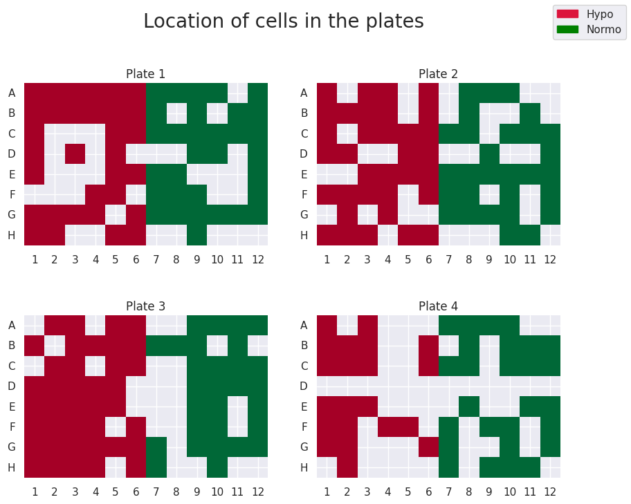

```python
#Maps
plate_1_pos = plate_1_meta[['Pos','Pos']].copy()
plate_1_pos.columns = ['Letter','Number']
for i,p in plate_1_pos.iterrows():
    p[0]=p[0][0]
    p[1]=int(p[1][1:])

plate_2_pos = plate_2_meta[['Pos','Pos']].copy()
plate_2_pos.columns = ['Letter','Number']
for i,p in plate_2_pos.iterrows():
    p[0]=p[0][0]
    p[1]=int(p[1][1:])

plate_3_pos = plate_3_meta[['Pos','Pos']].copy()
plate_3_pos.columns = ['Letter','Number']
for i,p in plate_3_pos.iterrows():
    p[0]=p[0][0]
    p[1]=int(p[1][1:])

plate_4_pos = plate_4_meta[['Pos','Pos']].copy()
plate_4_pos.columns = ['Letter','Number']
for i,p in plate_4_pos.iterrows():
    p[0]=p[0][0]
    p[1]=int(p[1][1:])


plate_1_values = pd.DataFrame(np.zeros((8,12)), index=list('ABCDEFGH'), columns=list(i+1 for i in range(12)))
for i in plate_1_pos.index:
    plate_1_values.loc[plate_1_pos.loc[i][0]][plate_1_pos.loc[i][1]] = (-1 if plate_1_meta.loc[i,'Condition']=='Hypo' else 1)
plate_2_values = pd.DataFrame(np.zeros((8,12)), index=list('ABCDEFGH'), columns=list(i+1 for i in range(12)))
for i in plate_2_pos.index:
    plate_2_values.loc[plate_2_pos.loc[i][0]][plate_2_pos.loc[i][1]] = (-1 if plate_2_meta.loc[i,'Condition']=='Hypo' else 1)
plate_3_values = pd.DataFrame(np.zeros((8,12)), index=list('ABCDEFGH'), columns=list(i+1 for i in range(12)))
for i in plate_3_pos.index:
    plate_3_values.loc[plate_3_pos.loc[i][0]][plate_3_pos.loc[i][1]] = (-1 if plate_3_meta.loc[i,'Condition']=='Hypo' else 1)
plate_4_values = pd.DataFrame(np.zeros((8,12)), index=list('ABCDEFGH'), columns=list(i+1 for i in range(12)))
for i in plate_4_pos.index:
    plate_4_values.loc[plate_4_pos.loc[i][0]][plate_4_pos.loc[i][1]] = (-1 if plate_4_meta.loc[i,'Condition']=='Hypo' else 1)

fig , ax = plt.subplots(2,2, figsize=(10,8))

h = sns.heatmap(plate_1_values, xticklabels=plate_1_values.columns, yticklabels=plate_1_values.index, cmap='RdYlGn', center=0, mask=(plate_1_values==0), ax=ax[0,0], square=True, cbar=False)
h.set_xticklabels(h.get_xticklabels(), rotation = 0)
h.set_yticklabels(h.get_yticklabels(), rotation = 0)
h = sns.heatmap(plate_2_values, xticklabels=plate_2_values.columns, yticklabels=plate_2_values.index, cmap='RdYlGn', center=0, mask=(plate_2_values==0), ax=ax[0,1], square=True, cbar=False)
h.set_xticklabels(h.get_xticklabels(), rotation = 0)
h.set_yticklabels(h.get_yticklabels(), rotation = 0)
h = sns.heatmap(plate_3_values, xticklabels=plate_3_values.columns, yticklabels=plate_3_values.index, cmap='RdYlGn', center=0, mask=(plate_3_values==0), ax=ax[1,0], square=True, cbar=False)
h.set_xticklabels(h.get_xticklabels(), rotation = 0)
h.set_yticklabels(h.get_yticklabels(), rotation = 0)
h = sns.heatmap(plate_4_values, xticklabels=plate_4_values.columns, yticklabels=plate_4_values.index, cmap='RdYlGn', center=0, mask=(plate_4_values==0), ax=ax[1,1], square=True, cbar=False)
h.set_xticklabels(h.get_xticklabels(), rotation = 0)
h.set_yticklabels(h.get_yticklabels(), rotation = 0)

ax[0,0].set_title('Plate 1')
ax[0,1].set_title('Plate 2')
ax[1,0].set_title('Plate 3')
ax[1,1].set_title('Plate 4')

fig.suptitle("Location of cells in the plates", fontsize=20)
red_patch = mpatches.Patch(color='crimson', label='Hypo')
green_patch = mpatches.Patch(color='green', label='Normo')
fig.legend(handles=[red_patch, green_patch], loc=1)
plt.show()
```

We can see that all the hypoxic cells are on the left half of the plates. Surely, this was done on purpose when sequencing the cells so we can exclude the proximity to cells of the same type as a relevant information.

Next we plot again the heatmap, giving to each cell its gene activation value, i.e. the number of genes that have an expression different from 0.

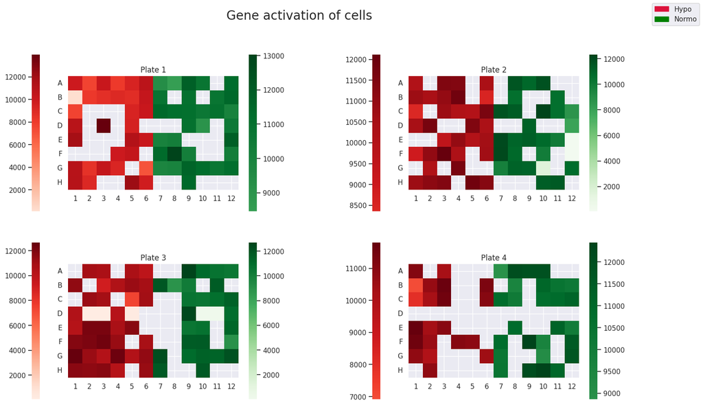

```python
plate_1_values = pd.DataFrame(np.zeros((8,12)), index=list('ABCDEFGH'), columns=list(i+1 for i in range(12)))
for i in plate_1_pos.index:
    plate_1_values.loc[plate_1_pos.loc[i][0]][plate_1_pos.loc[i][1]] = plate_1.loc[:,i].astype(bool).sum()
plate_2_values = pd.DataFrame(np.zeros((8,12)), index=list('ABCDEFGH'), columns=list(i+1 for i in range(12)))
for i in plate_2_pos.index:
    plate_2_values.loc[plate_2_pos.loc[i][0]][plate_2_pos.loc[i][1]] = plate_2.loc[:,i].astype(bool).sum()
plate_3_values = pd.DataFrame(np.zeros((8,12)), index=list('ABCDEFGH'), columns=list(i+1 for i in range(12)))
for i in plate_3_pos.index:
    plate_3_values.loc[plate_3_pos.loc[i][0]][plate_3_pos.loc[i][1]] = plate_3.loc[:,i].astype(bool).sum()
plate_4_values = pd.DataFrame(np.zeros((8,12)), index=list('ABCDEFGH'), columns=list(i+1 for i in range(12)))
for i in plate_4_pos.index:
    plate_4_values.loc[plate_4_pos.loc[i][0]][plate_4_pos.loc[i][1]] = plate_4.loc[:,i].astype(bool).sum()

fig , ax = plt.subplots(2,2, figsize=(18,10))

plate_1_hypo = plate_1_values.copy()
plate_1_hypo.iloc[:,6:]=0
plate_1_normo = plate_1_values.copy()
plate_1_normo.iloc[:,:6]=0

plate_2_hypo = plate_2_values.copy()
plate_2_hypo.iloc[:,6:]=0
plate_2_normo = plate_2_values.copy()
plate_2_normo.iloc[:,:6]=0

plate_3_hypo = plate_3_values.copy()
plate_3_hypo.iloc[:,6:]=0
plate_3_normo = plate_3_values.copy()
plate_3_normo.iloc[:,:6]=0

plate_4_hypo = plate_4_values.copy()
plate_4_hypo.iloc[:,6:]=0
plate_4_normo = plate_4_values.copy()
plate_4_normo.iloc[:,:6]=0


sns.heatmap(plate_1_hypo, xticklabels=plate_1_hypo.columns, yticklabels=plate_1_hypo.index, cmap='Reds', center=6000, mask=(plate_1_hypo==0), ax=ax[0,0], square=True, cbar_kws = {'location':'left'})
sns.heatmap(plate_2_hypo, xticklabels=plate_2_hypo.columns, yticklabels=plate_2_hypo.index, cmap='Reds', center=6000, mask=(plate_2_hypo==0), ax=ax[0,1], square=True, cbar_kws = {'location':'left'})
sns.heatmap(plate_3_hypo, xticklabels=plate_3_hypo.columns, yticklabels=plate_3_hypo.index, cmap='Reds', center=6000, mask=(plate_3_hypo==0), ax=ax[1,0], square=True, cbar_kws = {'location':'left'})
sns.heatmap(plate_4_hypo, xticklabels=plate_4_hypo.columns, yticklabels=plate_4_hypo.index, cmap='Reds', center=6000, mask=(plate_4_hypo==0), ax=ax[1,1], square=True, cbar_kws = {'location':'left'})

h = sns.heatmap(plate_1_normo, xticklabels=plate_1_normo.columns, yticklabels=plate_1_normo.index, cmap='Greens', center=6000, mask=(plate_1_normo==0), ax=ax[0,0], square=True)
h.set_xticklabels(h.get_xticklabels(), rotation = 0)
h.set_yticklabels(h.get_yticklabels(), rotation = 0)
h = sns.heatmap(plate_2_normo, xticklabels=plate_2_normo.columns, yticklabels=plate_2_normo.index, cmap='Greens', center=6000, mask=(plate_2_normo==0), ax=ax[0,1], square=True)
h.set_xticklabels(h.get_xticklabels(), rotation = 0)
h.set_yticklabels(h.get_yticklabels(), rotation = 0)
h = sns.heatmap(plate_3_normo, xticklabels=plate_3_normo.columns, yticklabels=plate_3_normo.index, cmap='Greens', center=6000, mask=(plate_3_normo==0), ax=ax[1,0], square=True)
h.set_xticklabels(h.get_xticklabels(), rotation = 0)
h.set_yticklabels(h.get_yticklabels(), rotation = 0)
h = sns.heatmap(plate_4_normo, xticklabels=plate_4_normo.columns, yticklabels=plate_4_normo.index, cmap='Greens', center=6000, mask=(plate_4_normo==0), ax=ax[1,1], square=True)
h.set_xticklabels(h.get_xticklabels(), rotation = 0)
h.set_yticklabels(h.get_yticklabels(), rotation = 0)

ax[0,0].set_title('Plate 1')
ax[0,1].set_title('Plate 2')
ax[1,0].set_title('Plate 3')
ax[1,1].set_title('Plate 4')

fig.suptitle("Gene activation of cells", fontsize=20)
red_patch = mpatches.Patch(color='crimson', label='Hypo')
green_patch = mpatches.Patch(color='green', label='Normo')
fig.legend(handles=[red_patch, green_patch], loc=1)
plt.show()
```

As we can see from the plot, in the frist three plates there are cells with a very low gene activation both among the hypoxic and the normal one, an issue that will be dealt with later on.  
By looking at the last plate we can also see that there may have been some issue in the processing of the cells, since there is a row that is completely blank, with no cell readings. Moreover, as we also noticed during the exploration of the dataset values we can see that the last plate has significantly less cells readings than the others, on the other hand there are no "dead" cells in that plate (cells with very low gene activation counts).

To gain an initial understanding of the data, we create boxplots and violin plots that depict the distribution shapes of gene expression profiles from a selected few cells. Moreover, we use violin plots to graphically represent the distribution of gene expression level for several genes across the cells.

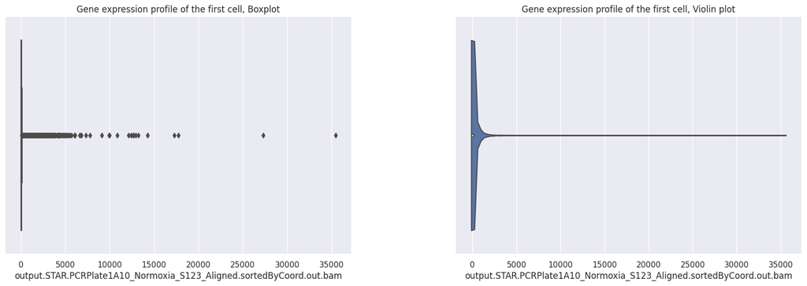

```python
fig, ax = plt.subplots( 1, 2, figsize = (20,6))
sns.set_style("white")
fig.subplots_adjust(hspace=0.3, wspace=0.3)

# Boxplot of gene expression profile of the first cell
cnames = list(df_hcc_smart_unfiltered.columns)
cnames[0]
sns.boxplot(x=df_hcc_smart_unfiltered[cnames[0]], ax=ax[0]).set_title('Gene expression profile of the first cell, Boxplot')

# Violin plot of gene expression of the first cell
sns.violinplot(x=df_hcc_smart_unfiltered[cnames[0]], ax=ax[1]).set_title('Gene expression profile of the first cell, Violin plot')
plt.show()
```

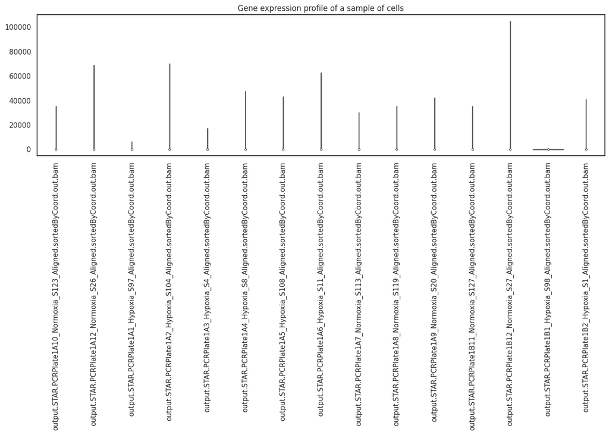

```python
# Plotting the violin plots of the gene expression of a sample of cells
plt.figure(figsize=(16,4))
plot=sns.violinplot(data=df_hcc_smart_unfiltered.iloc[:, :15],palette="Set3",cut=0)
plt.setp(plot.get_xticklabels(), rotation=90)
plt.title('Gene expression profile of a sample of cells')
plt.show()
```

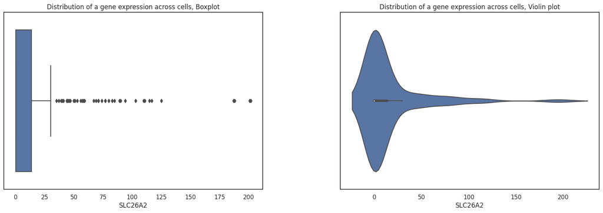

```python
fig, ax = plt.subplots( 1, 2, figsize = (20,6))
sns.set_style("white")
fig.subplots_adjust(hspace=0.3, wspace=0.3)

# Boxplot of the distribution of a gene expression level
sns.boxplot(x=df_hcc_smart_unfiltered.loc['SLC26A2', :], ax=ax[0]).set_title('Distribution of a gene expression across cells, Boxplot')
# Violin plot of the distribution of a gene expression level
sns.violinplot(x=df_hcc_smart_unfiltered.loc['SLC26A2', :], ax=ax[1]).set_title('Distribution of a gene expression across cells, Violin plot')
plt.show()
```

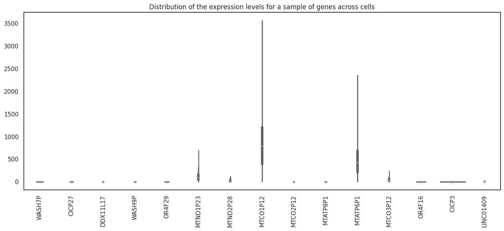

```python
# Distributions of the expression levels across cells for a sample of genes
plt.figure(figsize=(16, 6))
plot=sns.violinplot(data=df_hcc_smart_unfiltered.iloc[:15,:].T, palette='Set3', cut=0)
plt.setp(plot.get_xticklabels(), rotation=90)
plt.title('Distribution of the expression levels for a sample of genes across cells')
plt.show()
```

Our initial impression that the data is sparse, appears to be confirmed by these first graphs. Additionally, it is evident that some gene expressions are significantly larger than the majority.

## Filtering

### Check for duplicates

In data recording tasks, it is useful to check for duplicate rows; that is, pairs of genes that have the same counts across all cells. In our specific case, there may be certain features that have the same frequency across experiments but different names. This could be because of redundancy in gene annotation or overlapping gene annotations in the same region. If we retain both duplicates, we risk generating a biased result. Therefore, we examine and potentially keep one of the duplicate features, but it is important to document this action, as it may lead to issues with data interpretation in the future.

```python
duplicate_rows_df = df_hcc_smart_unfiltered[df_hcc_smart_unfiltered.duplicated(keep=False)]
print("number of duplicate rows: ", duplicate_rows_df.shape)
```

```
number of duplicate rows:  (89, 243)
```

There are 89 duplicate genes. Now we understand where the duplicates really are.

```python
print("names of duplicate rows: ",duplicate_rows_df.index)
duplicate_rows_df_t = duplicate_rows_df.T
duplicate_rows_df_t
c_dupl = duplicate_rows_df_t.corr()
c_dupl
```

```
names of duplicate rows:  Index(['MMP23A', 'LINC01647', 'LINC01361', 'ITGA10', 'RORC', 'GPA33', 'OR2M4',
       'LINC01247', 'SNORD92', 'LINC01106', 'ZBTB45P2', 'AOX3P', 'CPS1',
       'RPS3AP53', 'CCR4', 'RNY1P12', 'C4orf50', 'C4orf45', 'PCDHA2', 'PCDHA8',
       'PCDHGA2', 'PCDHGA3', 'PCDHGB3', 'PCDHGA7', 'PCDHGA9', 'PCDHGB7',
       'PCDHGA12', 'PCDHGB9P', 'PCDHGC4', 'SMIM23', 'PANDAR', 'LAP3P2',
       'RBBP4P3', 'RPL21P66', 'VNN3', 'TRPV6', 'CNPY1', 'ASS1P4', 'SLC7A3',
       'MIR374B', 'MIR374C', 'NAB1P1', 'RPL10AP3', 'MIR548AA1', 'MIR548D1',
       'SCARNA8', 'MIR3074', 'MIR24-1', 'SUGT1P4-STRA6LP', 'STRA6LP', 'KCNA4',
       'FBLIM1P2', 'APLNR', 'CYCSP26', 'OPCML', 'B3GAT1-DT', 'RPL21P88',
       'LINC02625', 'RPL22P18', 'PAX2', 'SOX5', 'COL2A1', 'LINC02395',
       'LDHAL6CP', 'CUX2', 'LINC00621', 'NUS1P2', 'UBBP5', 'OR5AU1',
       'LINC02833', 'RASL12', 'CILP', 'MIR6864', 'MIR4520-1', 'MIR4520-2',
       'CCL3L3', 'CCL3L1', 'RNU6-826P', 'OR4D1', 'MSX2P1', 'MIR548D2',
       'MIR548AA2', 'KCNJ16', 'CD300A', 'ENPP7', 'DTNA', 'ALPK2', 'OR7G2',
       'PLVAP'],
      dtype='object')
```

|  | MMP23A | LINC01647 | LINC01361 | ITGA10 | RORC | GPA33 | OR2M4 | LINC01247 | SNORD92 | LINC01106 | ... | MSX2P1 | MIR548D2 | MIR548AA2 | KCNJ16 | CD300A | ENPP7 | DTNA | ALPK2 | OR7G2 | PLVAP |
| --- | --- | --- | --- | --- | --- | --- | --- | --- | --- | --- | --- | --- | --- | --- | --- | --- | --- | --- | --- | --- | --- |
| MMP23A | 1.000000 | -0.008299 | -0.008299 | -0.008299 | -0.008299 | -0.008299 | -0.008299 | -0.008299 | -0.008299 | -0.010083 | ... | -0.008299 | -0.009421 | -0.009421 | -0.008299 | -0.008299 | -0.008299 | -0.008299 | -0.006540 | -0.008299 | -0.008299 |
| LINC01647 | -0.008299 | 1.000000 | 0.495851 | 0.495851 | -0.008299 | 0.495851 | -0.008299 | 0.495851 | -0.008299 | 0.234944 | ... | -0.008299 | -0.009421 | -0.009421 | 0.495851 | 0.495851 | 0.495851 | 0.495851 | 0.788121 | 0.495851 | 0.495851 |
| LINC01361 | -0.008299 | 0.495851 | 1.000000 | 1.000000 | 0.495851 | 1.000000 | 0.495851 | 0.495851 | -0.008299 | -0.010083 | ... | -0.008299 | -0.009421 | -0.009421 | 0.495851 | 1.000000 | 0.495851 | 1.000000 | 0.081755 | 0.495851 | 1.000000 |
| ITGA10 | -0.008299 | 0.495851 | 1.000000 | 1.000000 | 0.495851 | 1.000000 | 0.495851 | 0.495851 | -0.008299 | -0.010083 | ... | -0.008299 | -0.009421 | -0.009421 | 0.495851 | 1.000000 | 0.495851 | 1.000000 | 0.081755 | 0.495851 | 1.000000 |
| RORC | -0.008299 | -0.008299 | 0.495851 | 0.495851 | 1.000000 | 0.495851 | 1.000000 | -0.008299 | -0.008299 | -0.010083 | ... | -0.008299 | -0.009421 | -0.009421 | -0.008299 | 0.495851 | -0.008299 | 0.495851 | -0.006540 | -0.008299 | 0.495851 |
| ... | ... | ... | ... | ... | ... | ... | ... | ... | ... | ... | ... | ... | ... | ... | ... | ... | ... | ... | ... | ... | ... |
| ENPP7 | -0.008299 | 0.495851 | 0.495851 | 0.495851 | -0.008299 | 0.495851 | -0.008299 | 0.495851 | -0.008299 | -0.010083 | ... | -0.008299 | -0.009421 | -0.009421 | 0.495851 | 0.495851 | 1.000000 | 0.495851 | 0.081755 | 0.495851 | 0.495851 |
| DTNA | -0.008299 | 0.495851 | 1.000000 | 1.000000 | 0.495851 | 1.000000 | 0.495851 | 0.495851 | -0.008299 | -0.010083 | ... | -0.008299 | -0.009421 | -0.009421 | 0.495851 | 1.000000 | 0.495851 | 1.000000 | 0.081755 | 0.495851 | 1.000000 |
| ALPK2 | -0.006540 | 0.788121 | 0.081755 | 0.081755 | -0.006540 | 0.081755 | -0.006540 | 0.081755 | -0.006540 | 0.335362 | ... | -0.006540 | -0.007425 | -0.007425 | 0.081755 | 0.081755 | 0.081755 | 0.081755 | 1.000000 | 0.081755 | 0.081755 |
| OR7G2 | -0.008299 | 0.495851 | 0.495851 | 0.495851 | -0.008299 | 0.495851 | -0.008299 | 0.495851 | -0.008299 | -0.010083 | ... | -0.008299 | -0.009421 | -0.009421 | 0.495851 | 0.495851 | 0.495851 | 0.495851 | 0.081755 | 1.000000 | 0.495851 |
| PLVAP | -0.008299 | 0.495851 | 1.000000 | 1.000000 | 0.495851 | 1.000000 | 0.495851 | 0.495851 | -0.008299 | -0.010083 | ... | -0.008299 | -0.009421 | -0.009421 | 0.495851 | 1.000000 | 0.495851 | 1.000000 | 0.081755 | 0.495851 | 1.000000 |

89 rows × 89 columns

We look at the statistics of the gene expression profiles of genes that seem duplicates.

```python
duplicate_rows_df_t.describe()
```

|  | MMP23A | LINC01647 | LINC01361 | ITGA10 | RORC | GPA33 | OR2M4 | LINC01247 | SNORD92 | LINC01106 | ... | MSX2P1 | MIR548D2 | MIR548AA2 | KCNJ16 | CD300A | ENPP7 | DTNA | ALPK2 | OR7G2 | PLVAP |
| --- | --- | --- | --- | --- | --- | --- | --- | --- | --- | --- | --- | --- | --- | --- | --- | --- | --- | --- | --- | --- | --- |
| count | 243.000000 | 243.000000 | 243.000000 | 243.000000 | 243.000000 | 243.000000 | 243.000000 | 243.000000 | 243.000000 | 243.000000 | ... | 243.000000 | 243.000000 | 243.000000 | 243.000000 | 243.000000 | 243.000000 | 243.000000 | 243.000000 | 243.000000 | 243.000000 |
| mean | 0.008230 | 0.008230 | 0.008230 | 0.008230 | 0.008230 | 0.008230 | 0.008230 | 0.008230 | 0.008230 | 0.041152 | ... | 0.008230 | 0.024691 | 0.024691 | 0.008230 | 0.008230 | 0.008230 | 0.008230 | 0.037037 | 0.008230 | 0.008230 |
| std | 0.090534 | 0.090534 | 0.090534 | 0.090534 | 0.090534 | 0.090534 | 0.090534 | 0.090534 | 0.090534 | 0.372552 | ... | 0.090534 | 0.239247 | 0.239247 | 0.090534 | 0.090534 | 0.090534 | 0.090534 | 0.516931 | 0.090534 | 0.090534 |
| min | 0.000000 | 0.000000 | 0.000000 | 0.000000 | 0.000000 | 0.000000 | 0.000000 | 0.000000 | 0.000000 | 0.000000 | ... | 0.000000 | 0.000000 | 0.000000 | 0.000000 | 0.000000 | 0.000000 | 0.000000 | 0.000000 | 0.000000 | 0.000000 |
| 25% | 0.000000 | 0.000000 | 0.000000 | 0.000000 | 0.000000 | 0.000000 | 0.000000 | 0.000000 | 0.000000 | 0.000000 | ... | 0.000000 | 0.000000 | 0.000000 | 0.000000 | 0.000000 | 0.000000 | 0.000000 | 0.000000 | 0.000000 | 0.000000 |
| 50% | 0.000000 | 0.000000 | 0.000000 | 0.000000 | 0.000000 | 0.000000 | 0.000000 | 0.000000 | 0.000000 | 0.000000 | ... | 0.000000 | 0.000000 | 0.000000 | 0.000000 | 0.000000 | 0.000000 | 0.000000 | 0.000000 | 0.000000 | 0.000000 |
| 75% | 0.000000 | 0.000000 | 0.000000 | 0.000000 | 0.000000 | 0.000000 | 0.000000 | 0.000000 | 0.000000 | 0.000000 | ... | 0.000000 | 0.000000 | 0.000000 | 0.000000 | 0.000000 | 0.000000 | 0.000000 | 0.000000 | 0.000000 | 0.000000 |
| max | 1.000000 | 1.000000 | 1.000000 | 1.000000 | 1.000000 | 1.000000 | 1.000000 | 1.000000 | 1.000000 | 5.000000 | ... | 1.000000 | 3.000000 | 3.000000 | 1.000000 | 1.000000 | 1.000000 | 1.000000 | 8.000000 | 1.000000 | 1.000000 |

8 rows × 89 columns

The majority of the duplicates seem to be sparse. Next, we remove them.

```python
df_noDup = df_hcc_smart_unfiltered.drop_duplicates()
```

```python
df_noDup.shape
```

```
(23342, 243)
```

### Sparsity and Outliers

A dataset is said to be sparse when the data stored for a particular feature contains mostly zeroes. This could cause machine learning models to operate in a biased behaviour. There are several strategies to solve data sparsity, which we will investigate.

As previously noted, both the data referring to gene expression across cells and the gene expression profile of single cells are sparse: most of the entries are zeros (more than 50%). Moreover, it is interesting to notice that there are some very big outliers. Both of these features of the dataset will be further investigated throughout the report.

#### Outliers

As previously mentioned, our dataset seems to present a lot of outliers. We try to recognise outliers by computing the interquartile range for each feature, and by looking for those values in our dataset that have a distance larger than 1.5 times the interquartile range from the closest between the first and the third quartile.

We first compute the interquartile range for the gene expression levels in cells.

```python
Q1 = df_hcc_smart_unfiltered.T.quantile(0.25)
Q3 = df_hcc_smart_unfiltered.T.quantile(0.75)
IQR = Q3 - Q1
IQR.value_counts()
```

```
0.0       10145
1.0         700
2.0         330
3.0         225
4.0         181
          ...
1528.5        1
370.5         1
635.5         1
278.0         1
1979.5        1
Length: 1539, dtype: int64
```

10 145 genes have an interquartile range 0. This means that most of their readings across cells share the same value and by our previous investigation we know that that value must be 0. Therefore, as previously discussed, the data is very sparse.

As mentioned, we define "outliers" those values in our dataset that have a distance larger than 1.5 times the interquartile range from the closest between the first and the third quartile.

```python
low_bound = (Q1 - 1.5*IQR)
high_bound = (Q3 + 1.5*IQR)
```

We only want to keep those cells that have no outlier values among their features

```python
msk = (df_hcc_smart_unfiltered.T < low_bound) | (df_hcc_smart_unfiltered.T > high_bound)
df_filt = df_hcc_smart_unfiltered.T[~ msk.any(axis=1)]
df_filt.shape
```

```
(0, 23396)
```

By filtering the data according to the absence of outlier values among their features, all the cells have been removed. So, this strategy doesn't work. We apply an analogous strategy on the genes' expressions.

```python
Q1 = df_hcc_smart_unfiltered.quantile(0.25)
Q3 = df_hcc_smart_unfiltered.quantile(0.75)
IQR = Q3 - Q1
IQR.value_counts()
```

```
22.0     9
0.0      9
16.0     7
29.0     7
25.0     7
        ..
132.0    1
6.0      1
84.0     1
28.0     1
41.0     1
Length: 102, dtype: int64
```

```python
low_bound = (Q1 - 1.5*IQR).T
high_bound = (Q3 + 1.5*IQR).T
```

```python
msk = (df_hcc_smart_unfiltered < low_bound) | (df_hcc_smart_unfiltered > high_bound)
df_filt = df_hcc_smart_unfiltered[~ msk.any(axis=1)]
df_filt.shape
```

```
(10815, 243)
```

About half of the genes have now been cut.

We analyse how this filtering affected our previously built violin plots.

[figure not shown]

```python
plt.figure(figsize=(16, 6))
sns.violinplot(data=df_filt.iloc[:,:30], palette='Set3', cut=0)
plt.xticks(rotation=90)
plt.title("New distributions of the expression levels across cells for a sample of genes")
plt.show()
```

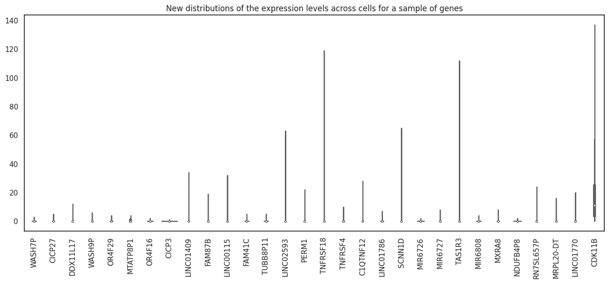

```python
plt.figure(figsize=(16, 6))
sns.violinplot(data=df_filt.iloc[:30,:].T, palette='Set3', cut=0)
plt.xticks(rotation=90)
plt.title("New distributions of the expression levels across cells for a sample of genes")
plt.show()
```

In order to calculate sparsity, one can divide the overall number of zero-valued elements by the total number of elements in a dataset. This is often defined as the "sparsity of the matrix".

```python
print("sparsity level:")
print("without outliers:", (df_filt == 0).sum().sum() / df_filt.size)
print("with outliers:", (df_hcc_smart_unfiltered == 0).sum().sum() / df_hcc_smart_unfiltered.size)
```

```
sparsity level:
without outliers: 0.8673120133026642
with outliers: 0.558456230779135
```

We obtain an unsatisfactory result: the post-filtering data are even more sparse than the original data. Therefore, our filtering method must be reshaped. We learn that we cannot simply filter the data by the outliers, because they often carry some important information for our inquiry.

#### Sparsity of genes

Very sparse genes are generally expressed in a few amount of cells. We do not expect sparse genes to be relevant for the classification, since they add little information about the cells in which they are observed.

As previously detected, the sparsity level of our dataset is just above 0.5:

```python
print("sparsity level:", (df_hcc_smart_unfiltered == 0).sum().sum() / df_hcc_smart_unfiltered.size)
```

```
sparsity level: 0.558456230779135
```

We now compute the individual sparsity level of each gene, and the sparsity level of the expression level of genes across cells.

```python
sparsity_levels_genes = (df_hcc_smart_unfiltered.T==0).sum() / df_hcc_smart_unfiltered.T.shape[0]
sparsity_levels_genes
```

```
WASH7P      0.975309
CICP27      0.946502
DDX11L17    0.823045
WASH9P      0.860082
OR4F29      0.901235
              ...
MT-TE       0.078189
MT-CYB      0.032922
MT-TT       0.074074
MT-TP       0.041152
MAFIP       0.296296
Length: 23396, dtype: float64
```

```python
sparsity_levels_cells = (df_hcc_smart_unfiltered==0).sum() / df_hcc_smart_unfiltered.shape[0]
sparsity_levels_cells.sort_values()
```

```
output.STAR.PCRPlate1D3_Hypoxia_S6_Aligned.sortedByCoord.out.bam        0.402206
output.STAR.PCRPlate1F8_Normoxia_S18_Aligned.sortedByCoord.out.bam      0.443110
output.STAR.PCRPlate3A9_Normoxia_S83_Aligned.sortedByCoord.out.bam      0.457258
output.STAR.PCRPlate3G1_Hypoxia_S164_Aligned.sortedByCoord.out.bam      0.458882
output.STAR.PCRPlate3D9_Normoxia_S86_Aligned.sortedByCoord.out.bam      0.466105
                                                                          ...
output.STAR.PCRPlate2F12_Normoxia_S62_Aligned.sortedByCoord.out.bam     0.996367
output.STAR.PCRPlate3D2_Hypoxia_S168_Aligned.sortedByCoord.out.bam      0.996538
output.STAR.PCRPlate3D10_Normoxia_S188_Aligned.sortedByCoord.out.bam    0.996965
output.STAR.PCRPlate2E12_Normoxia_S61_Aligned.sortedByCoord.out.bam     0.997136
output.STAR.PCRPlate3D11_Normoxia_S92_Aligned.sortedByCoord.out.bam     0.998504
Length: 243, dtype: float64
```

We represent these sparsity levels in their corresponding histograms

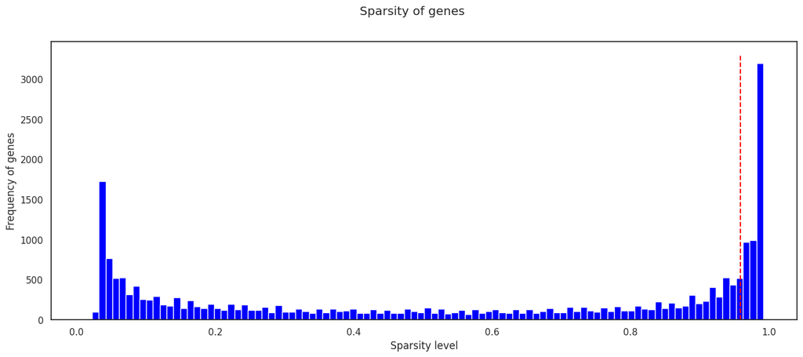

```python
fig, ax = plt.subplots(figsize=(16, 6))
sns.set_style("white")

bars = ax.hist(sparsity_levels_genes, bins = 100, color = 'blue')

# Labels
fig.suptitle("Sparsity of genes")
ax.set_xlabel("Sparsity level")
ax.set_ylabel("Frequency of genes");

sparsity_threshold = 0.9588477366255144

ax.plot([sparsity_threshold, sparsity_threshold], [0, 3300], color='red', linestyle='dashed')

sns.set_theme()
```

We can easily notice that the distribution of the sparsity level of genes has two tall peaks at its extremes. We aim at filtering the data that is extremely sparse, since it may cause a decrease in the performance of our algorithms.

Hence, we filter out those genes that are expressed in ten or less cells.

```python
sparsity_threshold = -((10 - df_hcc_smart_unfiltered.T.shape[0])/df_hcc_smart_unfiltered.T.shape[0])
sparsity_threshold
```

```
0.9588477366255144
```

```python
sparse_genes = (sparsity_levels_genes > sparsity_threshold)
df_genes_not_sparse = df_hcc_smart_unfiltered.T.drop(df_hcc_smart_unfiltered.T.columns[sparse_genes], axis=1)
print('Number of relevant genes:',df_genes_not_sparse.shape[1])
```

```
Number of relevant genes: 18239
```

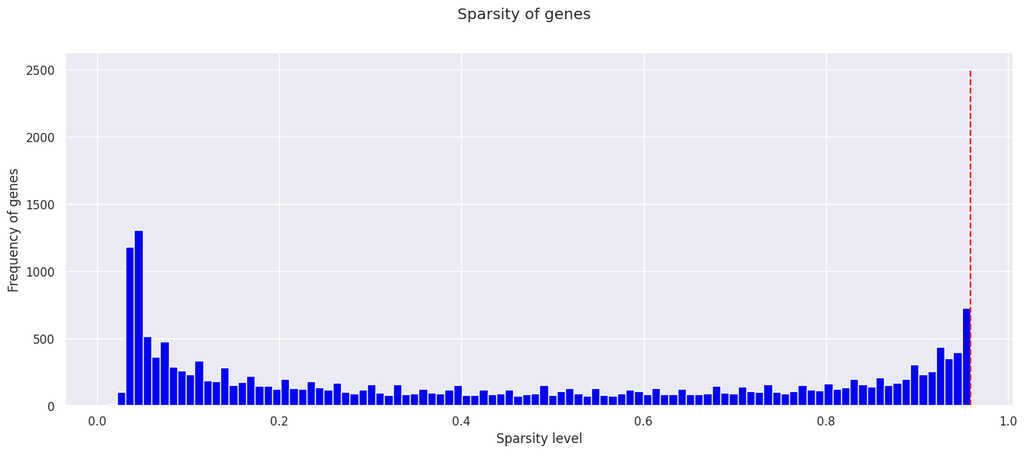

```python
sparsity_levels_genes_not_sparse = (df_genes_not_sparse==0).sum() / df_genes_not_sparse.shape[0]
fig, ax = plt.subplots(figsize=(16, 6))
sns.set_style("white")

bars = ax.hist(sparsity_levels_genes_not_sparse, bins = 100, color = 'blue')

fig.suptitle("Sparsity of genes")
ax.set_xlabel("Sparsity level")
ax.set_ylabel("Frequency of genes");

sparsity_threshold = 0.9588477366255144

ax.plot([sparsity_threshold, sparsity_threshold], [0, 2500], color='red', linestyle='dashed')

sns.set_theme()
```

```python
not_sparse_genes = (sparsity_levels_genes <= sparsity_threshold)
df_genes_sparse = df_hcc_smart_unfiltered.T.drop(df_hcc_smart_unfiltered.T.columns[not_sparse_genes], axis=1)
print('Number of sparse genes:',df_genes_sparse.shape[1])
```

```
Number of sparse genes: 5157
```

### Variability

We aim to delete from our dataset those genes that have the lowest variability. Indeed, these are the genes that appear with similar frequencies in most cells, meaning that they add little information to our inquiry. In our inquiry, we will only keep the upper quartile of the vmr distribution.

```python
std_dev = df_hcc_smart_unfiltered.std(axis=1)
var = df_hcc_smart_unfiltered.var(axis=1)
```

```python
#Sort by standard deviation
sorted_std_dev = std_dev.sort_values(ascending=False)

# Sort by variance
sorted_variance = var.sort_values(ascending=False)
```

```python
sorted_std_dev
```

```
FTL           24669.076099
ACTB          18288.941367
FTH1          15853.673169
LDHA          14290.034283
BEST1         13738.877437
                  ...
HNRNPA1P13        0.090534
TXNDC8            0.090534
MIR138-1          0.090534
OR12D1            0.090534
SMYD3-IT1         0.090534
Length: 23396, dtype: float64
```

```python
sorted_variance
```

```
FTL           6.085633e+08
ACTB          3.344854e+08
FTH1          2.513390e+08
LDHA          2.042051e+08
BEST1         1.887568e+08
                  ...
SMYD3-IT1     8.196443e-03
TMSB4Y        8.196443e-03
HNRNPA1P13    8.196443e-03
EEF1GP8       8.196443e-03
C1GALT1P2     8.196443e-03
Length: 23396, dtype: float64
```

```python
mean_values = df_hcc_smart_unfiltered.mean(axis=1)
```

```python
sorted_mean = mean_values.sort_values(ascending=False)
```

```python
sorted_mean
```

```
ACTB          27087.000000
FTL           23305.798354
GAPDH         16000.962963
LDHA          15654.251029
FTH1          12939.954733
                  ...
CEACAM7           0.008230
ISCA1P2           0.008230
OPN4              0.008230
RPL7AP8           0.008230
HNRNPA1P19        0.008230
Length: 23396, dtype: float64
```

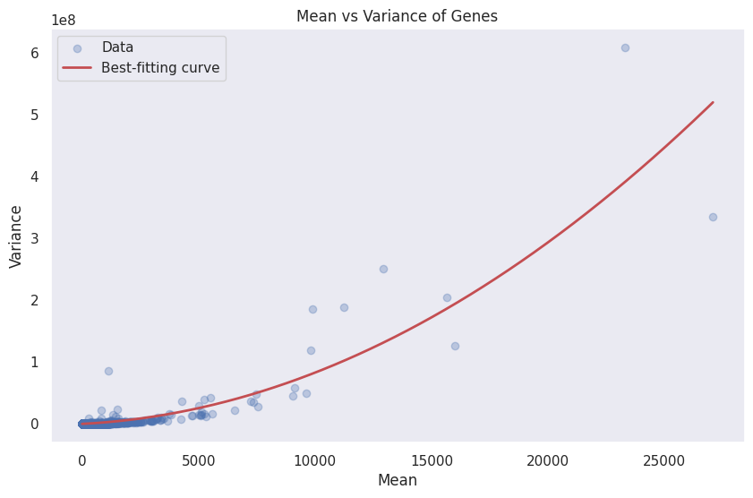

```python
# create a best fitting curve for the plot

from scipy.optimize import curve_fit

def polynomial_func(x, a, b, c):
    return a * x**2 + b * x + c

popt, _ = curve_fit(polynomial_func, mean_values, var)
a, b, c = popt

# create plot
plt.figure(figsize=(10, 6))
plt.scatter(mean_values, var, alpha = 0.3, label='Data')

# Plot the fitted curve
x_line = np.linspace(min(mean_values), max(mean_values), 1000)
y_line = polynomial_func(x_line, a, b, c)
plt.plot(x_line, y_line, 'r', label='Best-fitting curve', linewidth=2)

plt.xlabel('Mean')
plt.ylabel('Variance')
plt.title('Mean vs Variance of Genes')
plt.legend()
plt.grid()
plt.show()
```

Next we try applying different transformations to the data to better capture the differences in variability.

```python
# apply a log-transformation

log_df = np.log2(df_hcc_smart_unfiltered+1)
log_df.head()
```

|  | output.STAR.PCRPlate1A10_Normoxia_S123_Aligned.sortedByCoord.out.bam | output.STAR.PCRPlate1A12_Normoxia_S26_Aligned.sortedByCoord.out.bam | output.STAR.PCRPlate1A1_Hypoxia_S97_Aligned.sortedByCoord.out.bam | output.STAR.PCRPlate1A2_Hypoxia_S104_Aligned.sortedByCoord.out.bam | output.STAR.PCRPlate1A3_Hypoxia_S4_Aligned.sortedByCoord.out.bam | output.STAR.PCRPlate1A4_Hypoxia_S8_Aligned.sortedByCoord.out.bam | output.STAR.PCRPlate1A5_Hypoxia_S108_Aligned.sortedByCoord.out.bam | output.STAR.PCRPlate1A6_Hypoxia_S11_Aligned.sortedByCoord.out.bam | output.STAR.PCRPlate1A7_Normoxia_S113_Aligned.sortedByCoord.out.bam | output.STAR.PCRPlate1A8_Normoxia_S119_Aligned.sortedByCoord.out.bam | ... | output.STAR.PCRPlate4G12_Normoxia_S243_Aligned.sortedByCoord.out.bam | output.STAR.PCRPlate4G1_Hypoxia_S193_Aligned.sortedByCoord.out.bam | output.STAR.PCRPlate4G2_Hypoxia_S198_Aligned.sortedByCoord.out.bam | output.STAR.PCRPlate4G6_Hypoxia_S232_Aligned.sortedByCoord.out.bam | output.STAR.PCRPlate4G7_Normoxia_S204_Aligned.sortedByCoord.out.bam | output.STAR.PCRPlate4H10_Normoxia_S210_Aligned.sortedByCoord.out.bam | output.STAR.PCRPlate4H11_Normoxia_S214_Aligned.sortedByCoord.out.bam | output.STAR.PCRPlate4H2_Hypoxia_S199_Aligned.sortedByCoord.out.bam | output.STAR.PCRPlate4H7_Normoxia_S205_Aligned.sortedByCoord.out.bam | output.STAR.PCRPlate4H9_Normoxia_S236_Aligned.sortedByCoord.out.bam |
| --- | --- | --- | --- | --- | --- | --- | --- | --- | --- | --- | --- | --- | --- | --- | --- | --- | --- | --- | --- | --- | --- |
| WASH7P | 0.000000 | 0.0 | 0.0 | 0.0 | 0.0 | 0.0 | 0.0 | 0.0 | 0.0 | 0.0 | ... | 0.0 | 0.0 | 0.0 | 0.0 | 0.0 | 0.0 | 0.0 | 0.0 | 0.0 | 0.0 |
| CICP27 | 0.000000 | 0.0 | 0.0 | 0.0 | 0.0 | 0.0 | 0.0 | 0.0 | 0.0 | 0.0 | ... | 0.0 | 0.0 | 0.0 | 0.0 | 0.0 | 0.0 | 0.0 | 0.0 | 0.0 | 0.0 |
| DDX11L17 | 0.000000 | 0.0 | 0.0 | 0.0 | 0.0 | 1.0 | 0.0 | 0.0 | 0.0 | 0.0 | ... | 0.0 | 0.0 | 0.0 | 0.0 | 0.0 | 0.0 | 0.0 | 0.0 | 0.0 | 0.0 |
| WASH9P | 0.000000 | 0.0 | 0.0 | 0.0 | 0.0 | 0.0 | 0.0 | 0.0 | 1.0 | 0.0 | ... | 0.0 | 0.0 | 0.0 | 0.0 | 0.0 | 1.0 | 0.0 | 1.0 | 0.0 | 0.0 |
| OR4F29 | 1.584963 | 0.0 | 0.0 | 0.0 | 0.0 | 0.0 | 1.0 | 0.0 | 0.0 | 0.0 | ... | 0.0 | 0.0 | 0.0 | 0.0 | 0.0 | 0.0 | 0.0 | 0.0 | 0.0 | 0.0 |

5 rows × 243 columns

```python
# recalculate std, var, mean

log_std_dev = log_df.std(axis=1)
log_var = log_df.var(axis=1)
log_mean_values = log_df.mean(axis=1)
```

```python
#Sort by standard deviation
log_sorted_std_dev = log_std_dev.sort_values(ascending=False)

# Sort by variance
log_sorted_variance = log_var.sort_values(ascending=False)
```

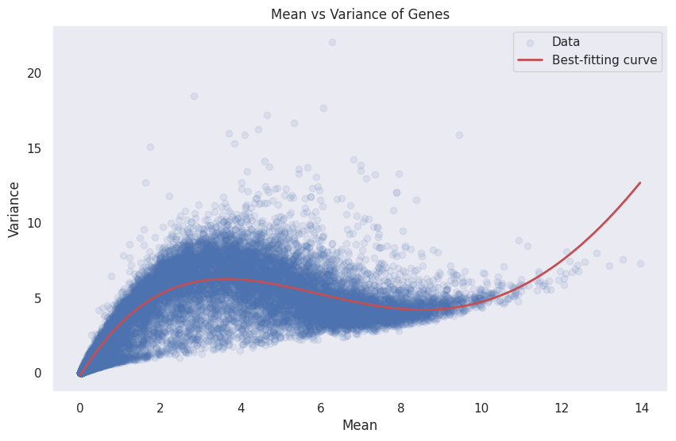

```python
# create a best fitting curve for the plot

from scipy.optimize import curve_fit

def polynomial_func(x, a, b, c, d, e):
    return a * x**4 + b * x**3 + c * x**2 + d * x + e

popt, _ = curve_fit(polynomial_func, log_mean_values, log_var)
a, b, c, d, e = popt

# create plot
plt.figure(figsize=(10, 6))
plt.scatter(log_mean_values, log_var, alpha = 0.1, label='Data')

# Plot the fitted curve
x_line = np.linspace(min(log_mean_values), max(log_mean_values), 1000)
y_line = polynomial_func(x_line, a, b, c, d, e)
plt.plot(x_line, y_line, 'r', label='Best-fitting curve', linewidth=2)

plt.xlabel('Mean')
plt.ylabel('Variance')
plt.title('Mean vs Variance of Genes')
plt.legend()
plt.grid()
plt.show()
```

```python
# apply a square-root transformation

sqrt_df = np.sqrt(df_hcc_smart_unfiltered)
sqrt_df.head()
```

|  | output.STAR.PCRPlate1A10_Normoxia_S123_Aligned.sortedByCoord.out.bam | output.STAR.PCRPlate1A12_Normoxia_S26_Aligned.sortedByCoord.out.bam | output.STAR.PCRPlate1A1_Hypoxia_S97_Aligned.sortedByCoord.out.bam | output.STAR.PCRPlate1A2_Hypoxia_S104_Aligned.sortedByCoord.out.bam | output.STAR.PCRPlate1A3_Hypoxia_S4_Aligned.sortedByCoord.out.bam | output.STAR.PCRPlate1A4_Hypoxia_S8_Aligned.sortedByCoord.out.bam | output.STAR.PCRPlate1A5_Hypoxia_S108_Aligned.sortedByCoord.out.bam | output.STAR.PCRPlate1A6_Hypoxia_S11_Aligned.sortedByCoord.out.bam | output.STAR.PCRPlate1A7_Normoxia_S113_Aligned.sortedByCoord.out.bam | output.STAR.PCRPlate1A8_Normoxia_S119_Aligned.sortedByCoord.out.bam | ... | output.STAR.PCRPlate4G12_Normoxia_S243_Aligned.sortedByCoord.out.bam | output.STAR.PCRPlate4G1_Hypoxia_S193_Aligned.sortedByCoord.out.bam | output.STAR.PCRPlate4G2_Hypoxia_S198_Aligned.sortedByCoord.out.bam | output.STAR.PCRPlate4G6_Hypoxia_S232_Aligned.sortedByCoord.out.bam | output.STAR.PCRPlate4G7_Normoxia_S204_Aligned.sortedByCoord.out.bam | output.STAR.PCRPlate4H10_Normoxia_S210_Aligned.sortedByCoord.out.bam | output.STAR.PCRPlate4H11_Normoxia_S214_Aligned.sortedByCoord.out.bam | output.STAR.PCRPlate4H2_Hypoxia_S199_Aligned.sortedByCoord.out.bam | output.STAR.PCRPlate4H7_Normoxia_S205_Aligned.sortedByCoord.out.bam | output.STAR.PCRPlate4H9_Normoxia_S236_Aligned.sortedByCoord.out.bam |
| --- | --- | --- | --- | --- | --- | --- | --- | --- | --- | --- | --- | --- | --- | --- | --- | --- | --- | --- | --- | --- | --- |
| WASH7P | 0.000000 | 0.0 | 0.0 | 0.0 | 0.0 | 0.0 | 0.0 | 0.0 | 0.0 | 0.0 | ... | 0.0 | 0.0 | 0.0 | 0.0 | 0.0 | 0.0 | 0.0 | 0.0 | 0.0 | 0.0 |
| CICP27 | 0.000000 | 0.0 | 0.0 | 0.0 | 0.0 | 0.0 | 0.0 | 0.0 | 0.0 | 0.0 | ... | 0.0 | 0.0 | 0.0 | 0.0 | 0.0 | 0.0 | 0.0 | 0.0 | 0.0 | 0.0 |
| DDX11L17 | 0.000000 | 0.0 | 0.0 | 0.0 | 0.0 | 1.0 | 0.0 | 0.0 | 0.0 | 0.0 | ... | 0.0 | 0.0 | 0.0 | 0.0 | 0.0 | 0.0 | 0.0 | 0.0 | 0.0 | 0.0 |
| WASH9P | 0.000000 | 0.0 | 0.0 | 0.0 | 0.0 | 0.0 | 0.0 | 0.0 | 1.0 | 0.0 | ... | 0.0 | 0.0 | 0.0 | 0.0 | 0.0 | 1.0 | 0.0 | 1.0 | 0.0 | 0.0 |
| OR4F29 | 1.414214 | 0.0 | 0.0 | 0.0 | 0.0 | 0.0 | 1.0 | 0.0 | 0.0 | 0.0 | ... | 0.0 | 0.0 | 0.0 | 0.0 | 0.0 | 0.0 | 0.0 | 0.0 | 0.0 | 0.0 |

5 rows × 243 columns

```python
# recalculate std, var, mean

sqrt_std_dev = sqrt_df.std(axis=1)
sqrt_var = sqrt_df.var(axis=1)
sqrt_mean_values = sqrt_df.mean(axis=1)
```

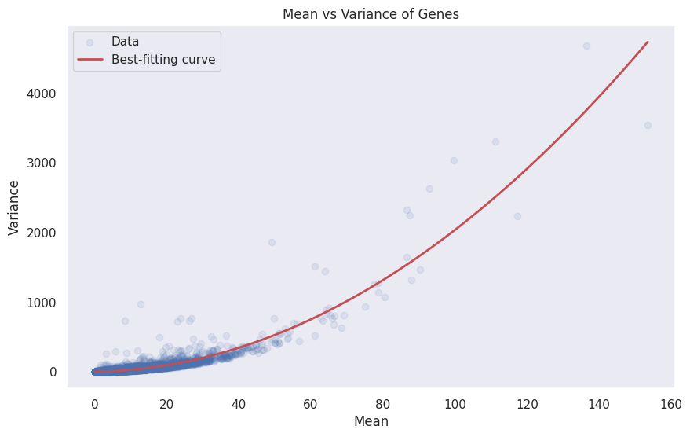

```python
# create a best fitting curve for the plot

from scipy.optimize import curve_fit

def polynomial_func(x, a, b, c):
    return a * x**2 + b * x + c

popt, _ = curve_fit(polynomial_func, sqrt_mean_values, sqrt_var)
a, b, c = popt

# create plot
plt.figure(figsize=(10, 6))
plt.scatter(sqrt_mean_values, sqrt_var, alpha = 0.1, label='Data')

# Plot the fitted curve
x_line = np.linspace(min(sqrt_mean_values), max(sqrt_mean_values), 1000)
y_line = polynomial_func(x_line, a, b, c)
plt.plot(x_line, y_line, 'r', label='Best-fitting curve', linewidth=2)

plt.xlabel('Mean')
plt.ylabel('Variance')
plt.title('Mean vs Variance of Genes')
plt.legend()
plt.grid()
plt.show()
```

We decide to work on the log-transformed data

We want to find an optimal threshold for filtering our data. Hence, we use an objective function to quantify how well the threshold separates the data into the desired groups. One common approach is to keep the upper quartile.

```python
# Calculate variance-to-mean ratio
vmr = log_var / log_mean_values

# Calculate the 75th percentile of the VMR values
vmr_threshold = vmr.quantile(0.75)
```

```python
# Get the column indices of genes with a VMR above the threshold
high_vmr_columns = vmr[vmr >= vmr_threshold].index

# Filter the DataFrame to keep only the genes with a high VMR
log_df_dispersed = df_hcc_smart_unfiltered.T[high_vmr_columns]
```

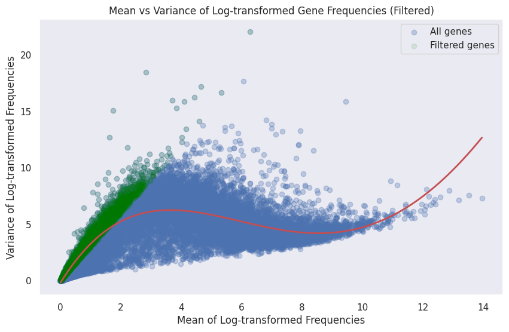

```python
# create a best fitting curve for the plot

from scipy.optimize import curve_fit

def polynomial_func(x, a, b, c, d, e):
    return a * x**4 + b * x**3 + c * x**2 + d * x + e

popt, _ = curve_fit(polynomial_func, log_mean_values, log_var)
a, b, c, d, e = popt

# create plot
plt.figure(figsize=(10, 6))

# Plot all the genes with low alpha
plt.scatter(log_mean_values, log_var, alpha=0.3, label='All genes')

# Highlight the filtered genes with a higher alpha and different color
high_vmr_indices = vmr[vmr >= vmr_threshold].index
plt.scatter(log_mean_values[high_vmr_indices], log_var[high_vmr_indices], alpha=0.1, color='green', label='Filtered genes')

# Plot the fitted curve
x_line = np.linspace(min(log_mean_values), max(log_mean_values), 1000)
y_line = polynomial_func(x_line, a, b, c, d, e)
plt.plot(x_line, y_line, 'r', linewidth=2)

plt.xlabel('Mean of Log-transformed Frequencies')
plt.ylabel('Variance of Log-transformed Frequencies')
plt.title('Mean vs Variance of Log-transformed Gene Frequencies (Filtered)')
plt.legend()
plt.grid()
plt.show()
```

```python
print("Number of dispersed genes:",log_df_dispersed.shape[1])
```

```
Number of dispersed genes: 5849
```

```python
# Filter the rows based on the presence of the index in log_df_dispersed
df_dispersed = df_hcc_smart_unfiltered.T.loc[:, df_hcc_smart_unfiltered.T.columns.isin(log_df_dispersed.columns)]
```

```python
df_dispersed.shape
```

```
(243, 5849)
```

### Mitochondria density

By looking at the mitochondrial density in cells, we are able to assess if we are dealing with damaged cells. Indeed, when cells are perforated, or dying, they present a large percentage of mithocondrial genes. This is because mitochondrial genes are larger and take more time leaving dying cells whose membrane has been damaged.

```python
mt_genes = np.array(df_hcc_smart_unfiltered.T.columns[df_hcc_smart_unfiltered.T.columns.str.startswith("MT-")])
print(mt_genes)
```

```
['MT-TF' 'MT-RNR1' 'MT-TV' 'MT-RNR2' 'MT-TL1' 'MT-ND1' 'MT-TI' 'MT-TQ'
 'MT-TM' 'MT-ND2' 'MT-TW' 'MT-TA' 'MT-TC' 'MT-TY' 'MT-CO1' 'MT-TS1'
 'MT-TD' 'MT-CO2' 'MT-TK' 'MT-ATP8' 'MT-ATP6' 'MT-CO3' 'MT-TG' 'MT-ND3'
 'MT-TR' 'MT-ND4L' 'MT-ND4' 'MT-TH' 'MT-TS2' 'MT-TL2' 'MT-ND5' 'MT-ND6'
 'MT-TE' 'MT-CYB' 'MT-TT' 'MT-TP']
```

```python
df_mt = df_hcc_smart_unfiltered.T.loc[:,mt_genes]
df_mt
```

|  | MT-TF | MT-RNR1 | MT-TV | MT-RNR2 | MT-TL1 | MT-ND1 | MT-TI | MT-TQ | MT-TM | MT-ND2 | ... | MT-ND4 | MT-TH | MT-TS2 | MT-TL2 | MT-ND5 | MT-ND6 | MT-TE | MT-CYB | MT-TT | MT-TP |
| --- | --- | --- | --- | --- | --- | --- | --- | --- | --- | --- | --- | --- | --- | --- | --- | --- | --- | --- | --- | --- | --- |
| output.STAR.PCRPlate1A10_Normoxia_S123_Aligned.sortedByCoord.out.bam | 3 | 662 | 13 | 9947 | 44 | 1123 | 3 | 7 | 10 | 1364 | ... | 17732 | 17 | 5 | 15 | 3852 | 900 | 22 | 4208 | 26 | 66 |
| output.STAR.PCRPlate1A12_Normoxia_S26_Aligned.sortedByCoord.out.bam | 13 | 1528 | 31 | 19835 | 111 | 2111 | 3 | 6 | 5 | 2069 | ... | 15624 | 49 | 29 | 36 | 7457 | 1439 | 43 | 6491 | 62 | 71 |
| output.STAR.PCRPlate1A1_Hypoxia_S97_Aligned.sortedByCoord.out.bam | 0 | 14 | 0 | 195 | 1 | 34 | 0 | 0 | 0 | 14 | ... | 200 | 0 | 0 | 0 | 93 | 12 | 0 | 25 | 0 | 1 |
| output.STAR.PCRPlate1A2_Hypoxia_S104_Aligned.sortedByCoord.out.bam | 1 | 453 | 0 | 5123 | 26 | 394 | 2 | 2 | 0 | 202 | ... | 6588 | 43 | 17 | 8 | 1479 | 234 | 0 | 4819 | 11 | 3 |
| output.STAR.PCRPlate1A3_Hypoxia_S4_Aligned.sortedByCoord.out.bam | 0 | 190 | 4 | 1950 | 9 | 174 | 1 | 1 | 4 | 82 | ... | 1028 | 0 | 0 | 3 | 303 | 33 | 0 | 310 | 4 | 9 |
| ... | ... | ... | ... | ... | ... | ... | ... | ... | ... | ... | ... | ... | ... | ... | ... | ... | ... | ... | ... | ... | ... |
| output.STAR.PCRPlate4H10_Normoxia_S210_Aligned.sortedByCoord.out.bam | 8 | 1005 | 10 | 8201 | 57 | 900 | 4 | 8 | 5 | 855 | ... | 6273 | 25 | 17 | 11 | 2926 | 423 | 26 | 3719 | 42 | 48 |
| output.STAR.PCRPlate4H11_Normoxia_S214_Aligned.sortedByCoord.out.bam | 0 | 132 | 2 | 1421 | 4 | 243 | 1 | 1 | 0 | 207 | ... | 1446 | 2 | 1 | 3 | 688 | 114 | 1 | 984 | 1 | 18 |
| output.STAR.PCRPlate4H2_Hypoxia_S199_Aligned.sortedByCoord.out.bam | 2 | 411 | 1 | 7836 | 29 | 542 | 1 | 9 | 9 | 558 | ... | 7026 | 9 | 6 | 23 | 2999 | 486 | 4 | 2256 | 15 | 36 |
| output.STAR.PCRPlate4H7_Normoxia_S205_Aligned.sortedByCoord.out.bam | 1 | 192 | 0 | 1475 | 20 | 230 | 1 | 2 | 2 | 183 | ... | 1201 | 2 | 3 | 3 | 611 | 75 | 4 | 981 | 6 | 8 |
| output.STAR.PCRPlate4H9_Normoxia_S236_Aligned.sortedByCoord.out.bam | 1 | 363 | 10 | 5531 | 55 | 1127 | 0 | 0 | 1 | 1151 | ... | 5341 | 14 | 3 | 15 | 2460 | 513 | 20 | 2039 | 34 | 79 |

243 rows × 36 columns

```python
mt_density = df_mt.sum(axis=1) / df_hcc_smart_unfiltered.T.sum(axis=1)
mt_density.sort_values(ascending=False)
```

```
output.STAR.PCRPlate3D2_Hypoxia_S168_Aligned.sortedByCoord.out.bam      0.492157
output.STAR.PCRPlate1G6_Hypoxia_S15_Aligned.sortedByCoord.out.bam       0.077753
output.STAR.PCRPlate4B1_Hypoxia_S221_Aligned.sortedByCoord.out.bam      0.067976
output.STAR.PCRPlate2G10_Normoxia_S157_Aligned.sortedByCoord.out.bam    0.050459
output.STAR.PCRPlate2C1_Hypoxia_S131_Aligned.sortedByCoord.out.bam      0.048678
                                                                          ...
output.STAR.PCRPlate1D3_Hypoxia_S6_Aligned.sortedByCoord.out.bam        0.004921
output.STAR.PCRPlate3D5_Hypoxia_S78_Aligned.sortedByCoord.out.bam       0.004622
output.STAR.PCRPlate1B1_Hypoxia_S98_Aligned.sortedByCoord.out.bam       0.002237
output.STAR.PCRPlate2A4_Hypoxia_S138_Aligned.sortedByCoord.out.bam      0.000435
output.STAR.PCRPlate3D10_Normoxia_S188_Aligned.sortedByCoord.out.bam    0.000000
Length: 243, dtype: float64
```

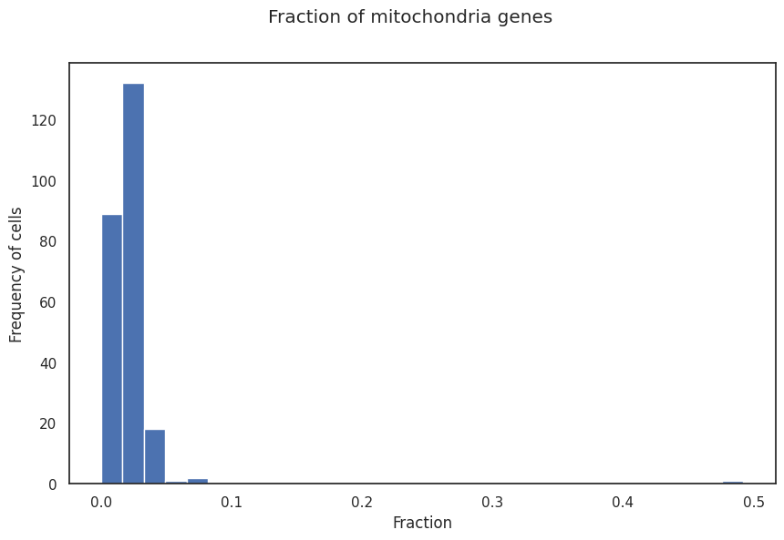

```python
fig = plt.figure(figsize=(10, 6))
sns.set_style("white")

ax1 = plt.axes()
ax1.hist(mt_density, bins = 30)

# Labels
fig.suptitle("Fraction of mitochondria genes")
ax1.set_xlabel("Fraction")
ax1.set_ylabel("Frequency of cells");

sns.set_theme() # resetting the style plot
```

We find that there is one strong outlier (around 0.5) to the main proportions of mitochondrial genes densities in our dataset. We want to filter that out.

```python
low_mt_density = mt_density[mt_density <= 0.1]
low_mt_density.sort_values(ascending=False)
```

```
output.STAR.PCRPlate1G6_Hypoxia_S15_Aligned.sortedByCoord.out.bam       0.077753
output.STAR.PCRPlate4B1_Hypoxia_S221_Aligned.sortedByCoord.out.bam      0.067976
output.STAR.PCRPlate2G10_Normoxia_S157_Aligned.sortedByCoord.out.bam    0.050459
output.STAR.PCRPlate2C1_Hypoxia_S131_Aligned.sortedByCoord.out.bam      0.048678
output.STAR.PCRPlate1H6_Hypoxia_S16_Aligned.sortedByCoord.out.bam       0.044875
                                                                          ...
output.STAR.PCRPlate1D3_Hypoxia_S6_Aligned.sortedByCoord.out.bam        0.004921
output.STAR.PCRPlate3D5_Hypoxia_S78_Aligned.sortedByCoord.out.bam       0.004622
output.STAR.PCRPlate1B1_Hypoxia_S98_Aligned.sortedByCoord.out.bam       0.002237
output.STAR.PCRPlate2A4_Hypoxia_S138_Aligned.sortedByCoord.out.bam      0.000435
output.STAR.PCRPlate3D10_Normoxia_S188_Aligned.sortedByCoord.out.bam    0.000000
Length: 242, dtype: float64
```

```python
low_mt_density.size
```

```
242
```

Let's now filter our original dataframe according to this measure.

```python
df_lowmt = df_hcc_smart_unfiltered.T.loc[low_mt_density.index]
df_lowmt.shape
```

```
(242, 23396)
```

## Filtered Data

Now that we filtered our data by duplicates, sparsity, variability and mithocondrial gene proportions, we can create a final dataframe that only contains those data that are kept during all previous precedures.

```python
common_columns = set(df_dispersed).intersection(set(df_genes_not_sparse), set(df_noDup.T), set(df_dispersed), set(df_lowmt))
common_rows = set(df_dispersed.T).intersection(set(df_genes_not_sparse.T), set(df_noDup), set(df_dispersed.T), set(df_lowmt.T))

df_filt = df_hcc_smart_unfiltered.T.loc[common_rows, common_columns]
```

```python
df_filt.shape
```

```
(242, 3979)
```

Before proceeding we check the frequency of cells in genes, such that we can verify if specific cells are outliers.

```python
list(df_filt.T.astype(bool).sum(axis=0).sort_values())
```

```
[3,
 5,
 6,
 8,
 12,
 13,
 14,
 54,
 314,
 349,
 398,
 399,
 409,
 431,
 441,
 447,
 447,
 450,
 466,
 469,
 502,
 503,
 508,
 511,
 521,
 524,
 525,
 525,
 527,
 534,
 564,
 567,
 576,
 587,
 595,
 598,
 598,
 617,
 627,
 639,
```

[output cut: 187 more lines]

```
 1297,
 1300,
 1306,
 1316,
 1332,
 1334,
 1336,
 1379,
 1449,
 1508,
 1523,
 1553,
 1585,
 1691,
 2116]
```

When studying the frequency of gene expressions in cells, we focus on both the number of features each cell presents and the number of counts of genes in the cell. We aim at filtering out the data that extremely low/high gene counts and extremely low/high features. Indeed, this allows us to to remove potential outliers or low-quality cells, as they can introduce noise and confounding factors that may negatively affect downstream analysis and interpretation of the data. These cells may not represent the true biological state, and their inclusion in the analysis can lead to spurious conclusions.

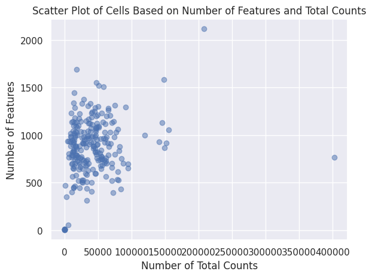

```python
# Calculate the number of unique genes (features) and total gene counts for each cell
total_features = df_filt.apply(lambda x: (x > 0).sum(), axis=1)
total_counts = df_filt.apply(lambda x: x.sum(), axis=1)

# Create the scatter plot
plt.scatter(total_counts, total_features, alpha=0.5)
plt.xlabel("Number of Total Counts")
plt.ylabel("Number of Features")
plt.title("Scatter Plot of Cells Based on Number of Features and Total Counts")

# Show the plot
plt.show()
```

Now, with the use of clustering methods, we can filter out the outliers, keeping the cells belonging to the main cluster.

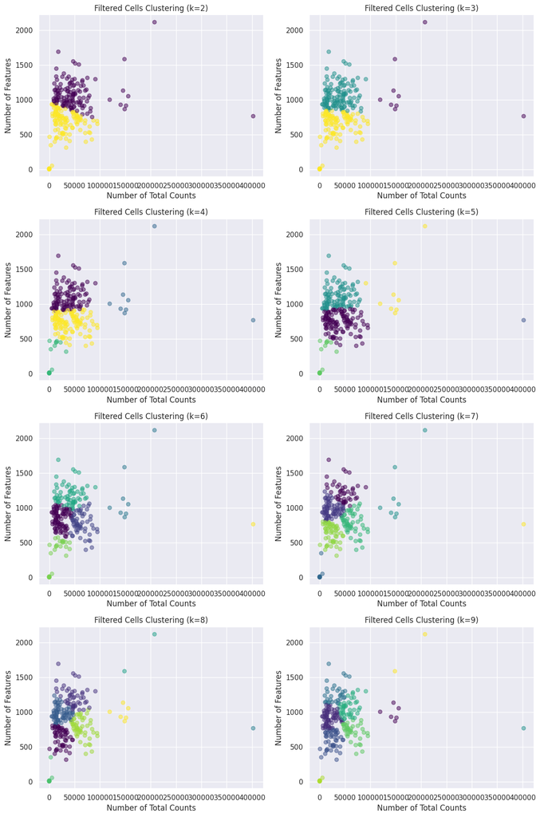

```python
from sklearn.cluster import KMeans
from sklearn.preprocessing import StandardScaler

# Standardize the data
scaler = StandardScaler()
data = np.column_stack((total_counts, total_features))
data_scaled = scaler.fit_transform(data)

# Set up the plot grid
fig, axes = plt.subplots(4, 2, figsize=(12, 18))

# Perform clustering with KMeans and create plots for different k values
for k in range(1, 9):
    row = (k - 1) // 2
    col = (k - 1) % 2

    kmeans = KMeans(n_clusters=k+1, n_init=10, random_state=0)
    cluster_labels = kmeans.fit_predict(data_scaled)

    # Plot the filtered cells and color them based on their cluster membership
    cmap = plt.get_cmap('viridis', k+1)
    scatter = axes[row, col].scatter(total_counts, total_features, c=cluster_labels, cmap=cmap, alpha=0.5)
    axes[row, col].set_xlabel("Number of Total Counts")
    axes[row, col].set_ylabel("Number of Features")
    axes[row, col].set_title(f"Filtered Cells Clustering (k={k+1})")

# Adjust the layout and show the plots
plt.tight_layout()
plt.show()
```

What is the optimal K? By using the silhouette method we should individuate it.

The Silhouette method calculates the silhouette coefficient for each point in the dataset, which is a measure of how similar a point is to its own cluster compared to other clusters. The optimal number of clusters is the one with the highest average silhouette coefficient.

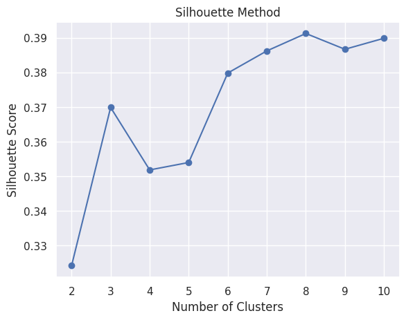

```python
from sklearn.metrics import silhouette_score

# Calculate silhouette scores for different numbers of clusters
silhouette_scores = []
num_clusters_range = range(2, 11)
for k in num_clusters_range:
    kmeans = KMeans(n_clusters=k, n_init=10, random_state=0)
    cluster_labels = kmeans.fit_predict(data_scaled)
    silhouette_scores.append(silhouette_score(data_scaled, cluster_labels))

# Plot the silhouette scores
plt.plot(num_clusters_range, silhouette_scores, marker='o')
plt.xlabel("Number of Clusters")
plt.ylabel("Silhouette Score")
plt.title("Silhouette Method")
plt.show()
```

We thus select "8" as our preferred K.

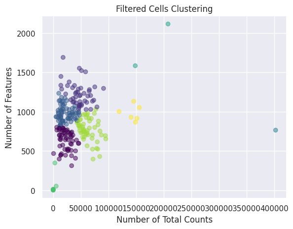

```python
# Standardize the data
scaler = StandardScaler()
data = np.column_stack((total_counts, total_features))
data_scaled = scaler.fit_transform(data)

# Perform clustering with KMeans
n_clusters = 8  # Change this value to choose the number of clusters
kmeans = KMeans(n_clusters=n_clusters, random_state=0)
cluster_labels = kmeans.fit_predict(data_scaled)

# Plot the filtered cells and color them based on their cluster membership
cmap = plt.cm.get_cmap('viridis', n_clusters)
plt.scatter(total_counts, total_features, c=cluster_labels, cmap=cmap, alpha=0.5)
plt.xlabel("Number of Total Counts")
plt.ylabel("Number of Features")
plt.title("Filtered Cells Clustering")

# Show the plot
plt.show()
```

Hence, we visually find 4 clusters that have very few cells, which also correspond to those clusters that are the most distant from all others. We treat these clusters as outliers, and try to filter them out.

```python
# Find the lables of the 4 clusters with the smallest amount of cells

# Create a DataFrame with cell names and their corresponding cluster labels
cell_cluster_labels = pd.DataFrame({'Cell': df_filt.index, 'Cluster': cluster_labels})

# Count the number of cells in each cluster
cluster_counts = cell_cluster_labels.groupby('Cluster').size()

# Find the labels of the 4 smallest clusters
smallest_clusters = cluster_counts.nsmallest(4).index.values

# Print the labels of the 4 smallest clusters
print("Labels of the 4 smallest clusters:", smallest_clusters)
```

```
Labels of the 4 smallest clusters: [3 4 7 5]
```

```python
# Create a boolean mask to identify the cells belonging to the outlier clusters
mask_outlier_clusters = np.isin(cluster_labels, smallest_clusters)

# Invert the mask to select the cells that don't belong to the distant clusters
mask_keep_clusters = ~mask_outlier_clusters

# Filter the DataFrame using the mask
df_filtered = df_filt[mask_keep_clusters]
```

Let us now represent the original graph while distinguishing the cells we keep in our dataset to those we filtered out

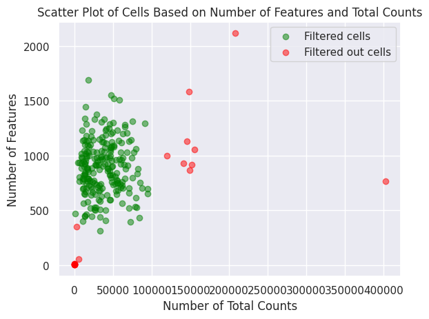

```python
# Calculate the number of unique genes (features) and total gene counts for each cell in both datasets
num_features_filt = df_filt.apply(lambda x: (x > 0).sum(), axis=1)
total_counts_filt = df_filt.apply(lambda x: x.sum(), axis=1)
num_features_filtered = df_filtered.apply(lambda x: (x > 0).sum(), axis=1)
total_counts_filtered = df_filtered.apply(lambda x: x.sum(), axis=1)

# Create the scatter plot for cells in df_filtered (green)
plt.scatter(total_counts_filtered, num_features_filtered, color='green', alpha=0.5, label='Filtered cells')

# Create the scatter plot for cells in df_filt but not in df_filtered (red)
cells_only_in_filt = df_filt.index.difference(df_filtered.index)
num_features_only_in_filt = num_features_filt.loc[cells_only_in_filt]
total_counts_only_in_filt = total_counts_filt.loc[cells_only_in_filt]
plt.scatter(total_counts_only_in_filt, num_features_only_in_filt, color='red', alpha=0.5, label='Filtered out cells')

plt.xlabel("Number of Total Counts")
plt.ylabel("Number of Features")
plt.title("Scatter Plot of Cells Based on Number of Features and Total Counts")
plt.legend()

# Show the plot
plt.show()
```

### Exploration of filtered data

We now repeat some EDA steps on our new filtered dataset.

```python
print("Dataframe dimensions:", np.shape(df_filtered))
```

```
Dataframe dimensions: (233, 3979)
```

Our dimension has drastically decreased (from 23396 genes to 3979).

```python
df_filtered.T.describe()
```

|  | output.STAR.PCRPlate4A1_Hypoxia_S220_Aligned.sortedByCoord.out.bam | output.STAR.PCRPlate2E6_Hypoxia_S48_Aligned.sortedByCoord.out.bam | output.STAR.PCRPlate3A2_Hypoxia_S166_Aligned.sortedByCoord.out.bam | output.STAR.PCRPlate1A12_Normoxia_S26_Aligned.sortedByCoord.out.bam | output.STAR.PCRPlate1E6_Hypoxia_S14_Aligned.sortedByCoord.out.bam | output.STAR.PCRPlate1C1_Hypoxia_S99_Aligned.sortedByCoord.out.bam | output.STAR.PCRPlate3H2_Hypoxia_S68_Aligned.sortedByCoord.out.bam | output.STAR.PCRPlate1F5_Hypoxia_S9_Aligned.sortedByCoord.out.bam | output.STAR.PCRPlate2A1_Hypoxia_S129_Aligned.sortedByCoord.out.bam | output.STAR.PCRPlate3E9_Normoxia_S87_Aligned.sortedByCoord.out.bam | ... | output.STAR.PCRPlate4G6_Hypoxia_S232_Aligned.sortedByCoord.out.bam | output.STAR.PCRPlate3G6_Hypoxia_S181_Aligned.sortedByCoord.out.bam | output.STAR.PCRPlate4C8_Normoxia_S208_Aligned.sortedByCoord.out.bam | output.STAR.PCRPlate2C11_Normoxia_S160_Aligned.sortedByCoord.out.bam | output.STAR.PCRPlate3C10_Normoxia_S187_Aligned.sortedByCoord.out.bam | output.STAR.PCRPlate4B8_Normoxia_S207_Aligned.sortedByCoord.out.bam | output.STAR.PCRPlate3F3_Hypoxia_S170_Aligned.sortedByCoord.out.bam | output.STAR.PCRPlate3F6_Hypoxia_S180_Aligned.sortedByCoord.out.bam | output.STAR.PCRPlate1C9_Normoxia_S22_Aligned.sortedByCoord.out.bam | output.STAR.PCRPlate4C11_Normoxia_S212_Aligned.sortedByCoord.out.bam |
| --- | --- | --- | --- | --- | --- | --- | --- | --- | --- | --- | --- | --- | --- | --- | --- | --- | --- | --- | --- | --- | --- |
| count | 3979.000000 | 3979.000000 | 3979.000000 | 3979.000000 | 3979.000000 | 3979.000000 | 3979.000000 | 3979.000000 | 3979.000000 | 3979.000000 | ... | 3979.000000 | 3979.000000 | 3979.000000 | 3979.000000 | 3979.000000 | 3979.000000 | 3979.000000 | 3979.000000 | 3979.000000 | 3979.000000 |
| mean | 8.368183 | 6.029404 | 4.555667 | 16.438050 | 5.462428 | 8.390550 | 3.481779 | 15.001257 | 2.708972 | 3.401357 | ... | 3.298567 | 11.598392 | 21.273687 | 3.344810 | 3.892184 | 3.077909 | 4.506911 | 7.845439 | 20.587082 | 2.221412 |
| std | 38.600803 | 48.681917 | 18.333816 | 62.549571 | 27.621222 | 49.370347 | 14.618041 | 65.282114 | 25.271562 | 13.916472 | ... | 29.875531 | 41.044698 | 384.867753 | 14.214164 | 14.407127 | 19.803229 | 12.566470 | 46.470223 | 70.569401 | 10.026410 |
| min | 0.000000 | 0.000000 | 0.000000 | 0.000000 | 0.000000 | 0.000000 | 0.000000 | 0.000000 | 0.000000 | 0.000000 | ... | 0.000000 | 0.000000 | 0.000000 | 0.000000 | 0.000000 | 0.000000 | 0.000000 | 0.000000 | 0.000000 | 0.000000 |
| 25% | 0.000000 | 0.000000 | 0.000000 | 0.000000 | 0.000000 | 0.000000 | 0.000000 | 0.000000 | 0.000000 | 0.000000 | ... | 0.000000 | 0.000000 | 0.000000 | 0.000000 | 0.000000 | 0.000000 | 0.000000 | 0.000000 | 0.000000 | 0.000000 |
| 50% | 0.000000 | 0.000000 | 0.000000 | 0.000000 | 0.000000 | 0.000000 | 0.000000 | 0.000000 | 0.000000 | 0.000000 | ... | 0.000000 | 0.000000 | 0.000000 | 0.000000 | 0.000000 | 0.000000 | 0.000000 | 0.000000 | 0.000000 | 0.000000 |
| 75% | 0.000000 | 0.000000 | 1.000000 | 0.000000 | 0.000000 | 0.000000 | 3.000000 | 0.000000 | 0.000000 | 0.000000 | ... | 0.000000 | 1.000000 | 0.000000 | 0.000000 | 0.000000 | 0.000000 | 5.000000 | 0.000000 | 0.000000 | 1.000000 |
| max | 1783.000000 | 2846.000000 | 584.000000 | 2503.000000 | 1149.000000 | 1896.000000 | 607.000000 | 2868.000000 | 1477.000000 | 539.000000 | ... | 1565.000000 | 1228.000000 | 23827.000000 | 652.000000 | 322.000000 | 1077.000000 | 487.000000 | 2417.000000 | 1651.000000 | 530.000000 |

8 rows × 233 columns

```python
print("sparsity level:", (df_filtered == 0).sum().sum() / df_filtered.size)
```

```
sparsity level: 0.7744791054322748
```

```python
df_filtered.describe()
```

|  | ADAMTSL5 | LINC02562 | TFCP2 | FABP6 | BCL6 | CYP2J2 | EPSTI1 | KLHL11 | MFHAS1 | RLN2 | ... | KRT80 | IRF7 | MAPK8IP2 | CNTLN | TAFA2 | BTBD7P1 | CNTN5 | TTN-AS1 | INHBB | EYA4 |
| --- | --- | --- | --- | --- | --- | --- | --- | --- | --- | --- | --- | --- | --- | --- | --- | --- | --- | --- | --- | --- | --- |
| count | 233.000000 | 233.000000 | 233.000000 | 233.000000 | 233.000000 | 233.000000 | 233.000000 | 233.000000 | 233.000000 | 233.000000 | ... | 233.000000 | 233.000000 | 233.000000 | 233.000000 | 233.000000 | 233.000000 | 233.000000 | 233.000000 | 233.000000 | 233.000000 |
| mean | 17.703863 | 3.227468 | 21.566524 | 6.523605 | 41.678112 | 3.493562 | 5.527897 | 9.690987 | 8.377682 | 0.369099 | ... | 28.497854 | 24.347639 | 2.098712 | 4.373391 | 0.424893 | 1.300429 | 1.862661 | 4.901288 | 2.424893 | 5.030043 |
| std | 36.928085 | 8.949317 | 35.066637 | 14.963767 | 96.242798 | 19.211868 | 14.566149 | 32.665081 | 24.066786 | 2.383725 | ... | 63.035781 | 47.165192 | 12.551056 | 10.718682 | 2.773750 | 4.257331 | 10.200491 | 13.589539 | 11.203628 | 14.554711 |
| min | 0.000000 | 0.000000 | 0.000000 | 0.000000 | 0.000000 | 0.000000 | 0.000000 | 0.000000 | 0.000000 | 0.000000 | ... | 0.000000 | 0.000000 | 0.000000 | 0.000000 | 0.000000 | 0.000000 | 0.000000 | 0.000000 | 0.000000 | 0.000000 |
| 25% | 0.000000 | 0.000000 | 0.000000 | 0.000000 | 0.000000 | 0.000000 | 0.000000 | 0.000000 | 0.000000 | 0.000000 | ... | 0.000000 | 0.000000 | 0.000000 | 0.000000 | 0.000000 | 0.000000 | 0.000000 | 0.000000 | 0.000000 | 0.000000 |
| 50% | 0.000000 | 0.000000 | 0.000000 | 0.000000 | 2.000000 | 0.000000 | 0.000000 | 0.000000 | 0.000000 | 0.000000 | ... | 0.000000 | 0.000000 | 0.000000 | 0.000000 | 0.000000 | 0.000000 | 0.000000 | 0.000000 | 0.000000 | 0.000000 |
| 75% | 20.000000 | 0.000000 | 30.000000 | 5.000000 | 44.000000 | 0.000000 | 2.000000 | 4.000000 | 5.000000 | 0.000000 | ... | 30.000000 | 32.000000 | 0.000000 | 2.000000 | 0.000000 | 0.000000 | 0.000000 | 0.000000 | 0.000000 | 1.000000 |
| max | 328.000000 | 70.000000 | 170.000000 | 90.000000 | 862.000000 | 232.000000 | 116.000000 | 402.000000 | 199.000000 | 27.000000 | ... | 548.000000 | 357.000000 | 129.000000 | 85.000000 | 33.000000 | 30.000000 | 93.000000 | 106.000000 | 118.000000 | 105.000000 |

8 rows × 3979 columns

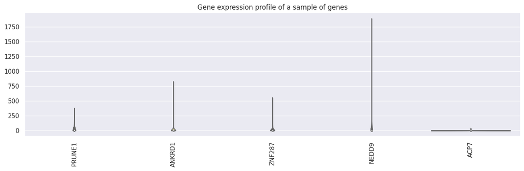

```python
# Plotting the violin plots of the gene expression for a sample of genes
plt.figure(figsize=(16,4))
plot=sns.violinplot(data=df_filtered.iloc[:, 20:25],palette="Set3",cut=0)
plt.setp(plot.get_xticklabels(), rotation=90)
plt.title('Gene expression profile of a sample of genes')
plt.show()
```

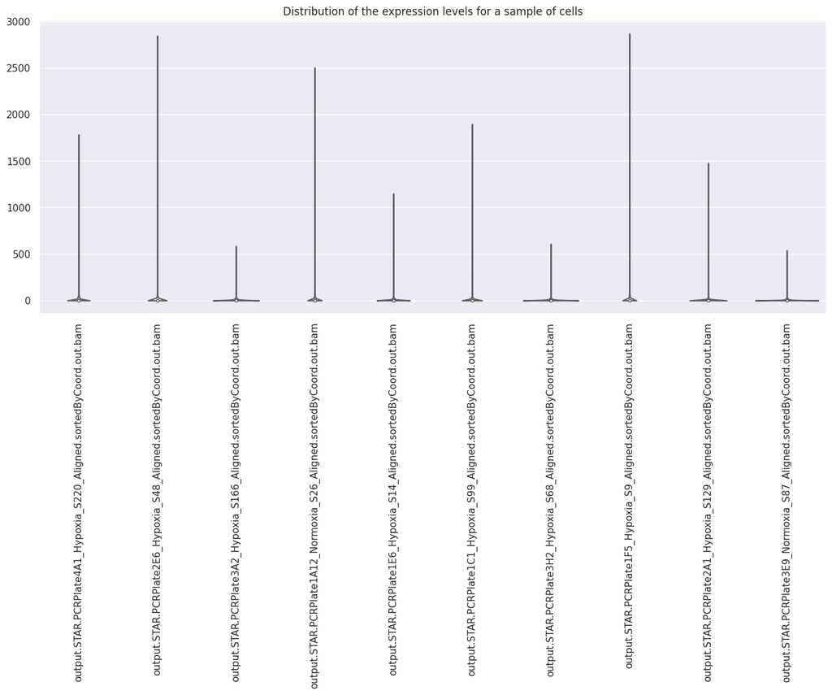

```python
# Distributions of the expression levels across cells for a sample of cells
plt.figure(figsize=(16, 6))
plot=sns.violinplot(data=df_filtered.iloc[:10,:].T, palette='Set3', cut=0)
plt.setp(plot.get_xticklabels(), rotation=90)
plt.title('Distribution of the expression levels for a sample of cells')
plt.show()
```

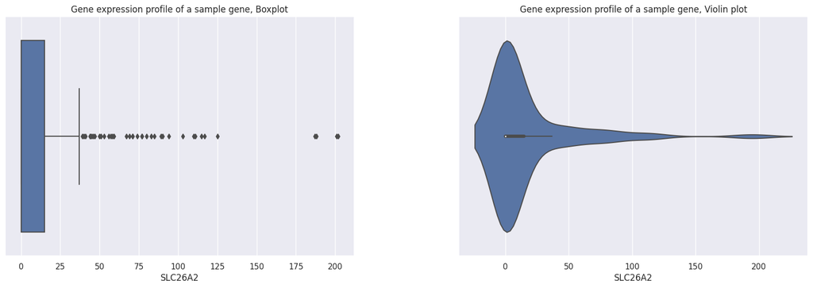

```python
fig, ax = plt.subplots( 1, 2, figsize = (20,6))
sns.set_style("white")
fig.subplots_adjust(hspace=0.3, wspace=0.3)

# Boxplot of gene expression profile of a sample gene
cnames = list(df_filtered.columns)
cnames[5]
sns.boxplot(x=df_filtered.T.loc['SLC26A2', :], ax=ax[0]).set_title('Gene expression profile of a sample gene, Boxplot')

# Violin plot of gene expression of a sample gene
sns.violinplot(x=df_filtered.T.loc['SLC26A2', :], ax=ax[1]).set_title('Gene expression profile of a sample gene, Violin plot')
plt.show()
```

We calculate the sparsity level of our new dataframe and represent it graphically.

```python
print("sparsity level:", (df_filtered == 0).sum().sum() / df_filtered.size)
sparsity_levels_genes = (df_filtered==0).sum() / df_filtered.shape[0]
sparsity_levels_genes
```

```
sparsity level: 0.7744791054322748
```

```
ADAMTSL5     0.549356
LINC02562    0.781116
TFCP2        0.506438
FABP6        0.699571
BCL6         0.463519
               ...
BTBD7P1      0.871245
CNTN5        0.939914
TTN-AS1      0.793991
INHBB        0.862661
EYA4         0.729614
Length: 3979, dtype: float64
```

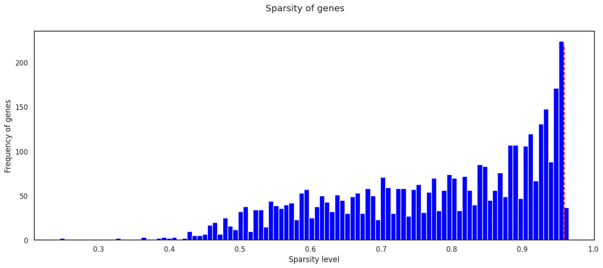

```python
fig = plt.figure(figsize=(16, 6))
sns.set_style("white")

ax1 = plt.axes()
bars = ax1.hist(sparsity_levels_genes, bins = 100, color = 'blue')

# Labels
fig.suptitle("Sparsity of genes")
ax1.set_xlabel("Sparsity level")
ax1.set_ylabel("Frequency of genes");

sparsity_threshold = 0.9588477366255144

ax1.plot([sparsity_threshold, sparsity_threshold], [0, 220], color='red', linestyle='dashed')

sns.set_theme() # resetting the style plot
```

One might argue that our filtering didn't work correctly, since there are some genes that appear to have a higher sparsity than our previously established threshold. However, this was to be expected: we filtered out sparse data before applying other filtering methods. During the succeeding filtering methods, we deleted non-zero entries, causing an increase in the overall ratio of null entries (sparsity).

## Normalization

After the data transformation we move on to better understanding if the data are normalized or not. We start by looking at the overall distribution of the gene expression of the cells.

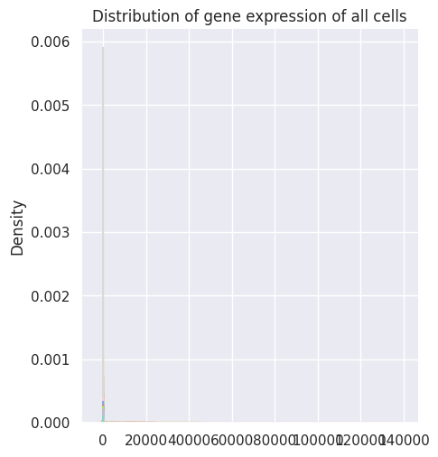

```python
sns.displot(data=df_filtered.T,palette="Set3",kind="kde", bw_adjust=2, legend=False)
plt.title('Distribution of gene expression of all cells')
```

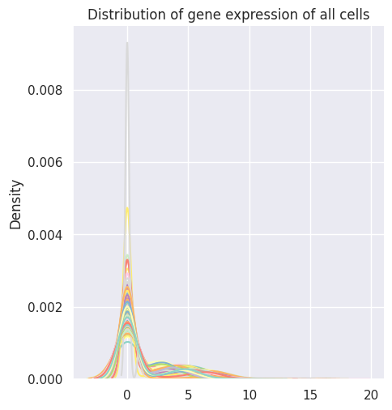

```python
sns.displot(data=(df_filtered.T+1).apply(np.log2),palette="Set3",kind="kde", bw_adjust=2, legend=False)
plt.title('Distribution of gene expression of all cells')
```

It's clear by looking at the graph that the data is not normalized, since the distributions of the gene expressions of the cells are very different and cover a wide range of values, but in a very uneven way across samples. This could be due to differences in the rilevation of the data or other types of outside noise, since we expect the distributions to be similar after having filtered the data.

Next we try different normalization techniques in order to solve this problem. We will combine the normalization with the log transformation, a techinque commonly used when dealing with data spanning across multiple orders of magnitude and whose usefulness will be further explained later. We try applying the log before and after the normalization, giving respectively more importance to the main body or to the tail of the distribution, in order to find the best approach. We could avoid this approach, but all we would see would be plots with a big spike at 0 and it wouldn't be possible to visually compare the normaliation techniques.

```python
df_filtered_log = (df_filtered+1).apply(np.log2)
```

MAX-MIN NORMALIZATIOM

```python
df_norm=df_filtered.T.copy()
for x in df_filtered.T.columns:
    df_norm.loc[:,x]=(df_filtered.T.loc[:,x]-df_filtered.T.loc[:,x].min())/(df_filtered.T.loc[:,x].max()-df_filtered.T.loc[:,x].min())
```

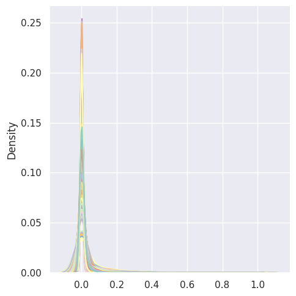

```python
sns.displot((df_norm+1).apply(np.log2),palette="Set3",kind="kde", bw_adjust=2, legend=False)
```

```python
df_norm_log=df_filtered_log.T.copy()
for x in df_filtered_log.T.columns:
    df_norm_log.loc[:,x]=(df_filtered_log.T.loc[:,x]-df_filtered_log.T.loc[:,x].min())/(df_filtered_log.T.loc[:,x].max()-df_filtered_log.T.loc[:,x].min())
```

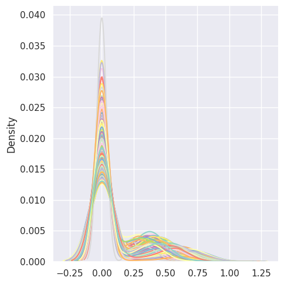

```python
sns.displot(data=(df_norm_log),palette="Set3",kind="kde", bw_adjust=2, legend=False)
```

STANDARDIZATION

```python
df_std=df_filtered.T.copy()
for x in df_filtered.T.columns:
    df_std.loc[:,x]=(df_filtered.T.loc[:,x]-df_filtered.T.loc[:,x].mean())/df_filtered.T.loc[:,x].std()
```

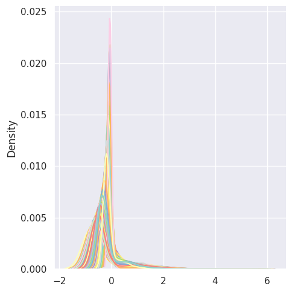

```python
sns.displot(data=(df_std+1).apply(np.log2),palette="Set3",kind="kde", bw_adjust=2, legend=False)
```

```python
df_std_log=df_filtered_log.T.copy()
for x in df_filtered_log.T.columns:
    df_std_log.loc[:,x]=(df_filtered_log.T.loc[:,x]-df_filtered_log.T.loc[:,x].mean())/df_filtered_log.T.loc[:,x].std()
```

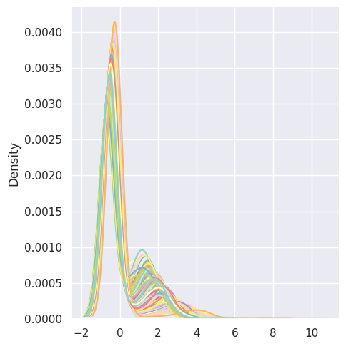

```python
sns.displot(data=(df_std_log),palette="Set3",kind="kde", bw_adjust=2, legend=False)
```

COUNTS PER MILLION

```python
df_cpm=df_filtered.T.copy()
for x in df_filtered.T.columns:
    df_cpm.loc[:,x] = (df_filtered.T.loc[:,x]*1e6)/(df_filtered.T.loc[:,x].sum())
```